# HW2

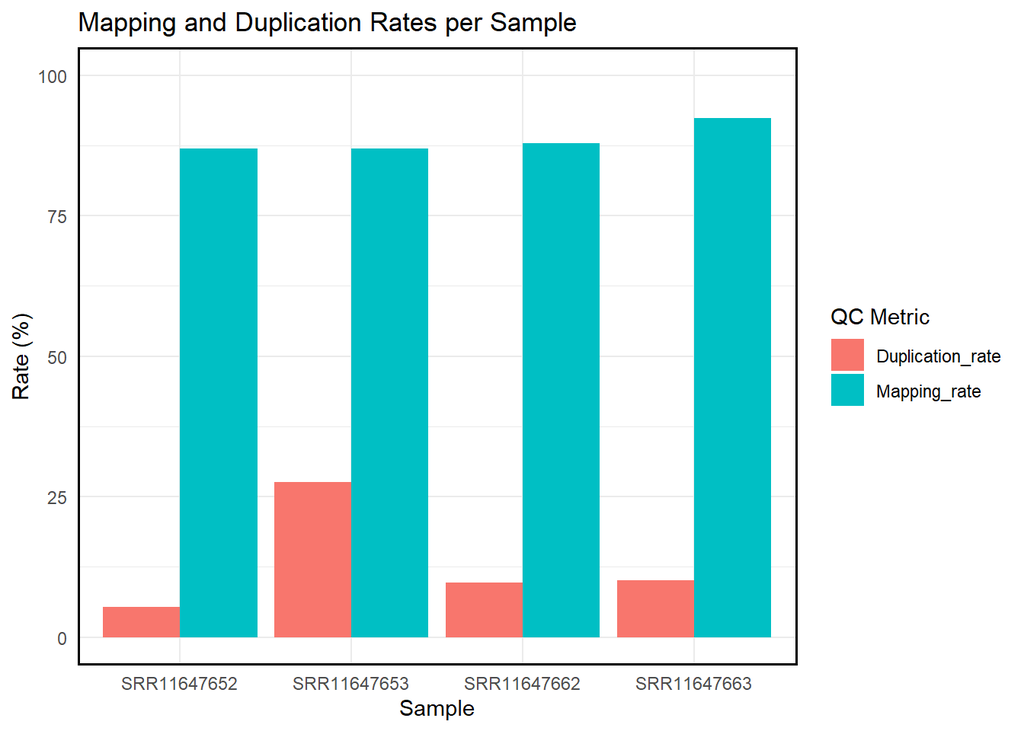

```r
setwd("C:/Users/Administrator/Desktop/Paskaitos 2/Big data analysis/HW2 metilinimas")

library(ggplot2)
library(tidyr)

# Create the data
qc_data <- data.frame(
  Sample = c("SRR11647652", "SRR11647653", "SRR11647662", "SRR11647663"),
  Duplication_rate = c(5.32, 27.53, 9.74, 10.08),
  Mapping_rate = c(86.9, 86.9, 87.9, 92.34)
)

# Convert to long format for plotting
qc_long <- pivot_longer(
  qc_data,
  cols = c(Duplication_rate, Mapping_rate),
  names_to = "Metric",
  values_to = "Percent"
)

# Plot
ggplot(qc_long, aes(x = Sample, y = Percent, fill = Metric)) +
  geom_bar(stat = "identity", position = "dodge") +
  scale_y_continuous(limits = c(0, 100)) +
  labs(
    title = "Mapping and Duplication Rates per Sample",
    x = "Sample",
    y = "Rate (%)",
    fill = "QC Metric"
  ) +
  theme_minimal() +
  theme(
    panel.border = element_rect(color = "black", fill = NA, linewidth = 1),
    legend.position = "right"
  )
```

```r
library(readr)
library(dplyr)

SRR11647652 <- read_tsv(
  "SRR11647652_methylation_chr20_CpG.bedGraph",
  comment = "t",
  col_names = c("chr", "start", "end", "methylation_percent", "methylated_reads", "unmethylated_reads")
)
SRR11647653 <- read_tsv(
  "SRR11647653_methylation_chr20_CpG.bedGraph",
  comment = "t",
  col_names = c("chr", "start", "end", "methylation_percent", "methylated_reads", "unmethylated_reads")
)
SRR11647662 <- read_tsv(
  "SRR11647662_methylation_chr20_CpG.bedGraph",
  comment = "t",
  col_names = c("chr", "start", "end", "methylation_percent", "methylated_reads", "unmethylated_reads")
)
SRR11647663 <- read_tsv(
  "SRR11647663_methylation_chr20_CpG.bedGraph",
  comment = "t",
  col_names = c("chr", "start", "end", "methylation_percent", "methylated_reads", "unmethylated_reads")
)


SRR11647652 <- SRR11647652 %>%
  mutate(
    coverage = methylated_reads + unmethylated_reads,
    methylation_fraction = methylation_percent / 100
  )
SRR11647653 <- SRR11647653 %>%
  mutate(
    coverage = methylated_reads + unmethylated_reads,
    methylation_fraction = methylation_percent / 100
  )
SRR11647662 <- SRR11647662 %>%
  mutate(
    coverage = methylated_reads + unmethylated_reads,
    methylation_fraction = methylation_percent / 100
  )
SRR11647663 <- SRR11647663 %>%
  mutate(
    coverage = methylated_reads + unmethylated_reads,
    methylation_fraction = methylation_percent / 100
  )
```

# Data QC and statistical analysis

Calculate and report:

- total number of reads per sample,
- coverage distribution per CpG,
- number of covered CpGs per sample.

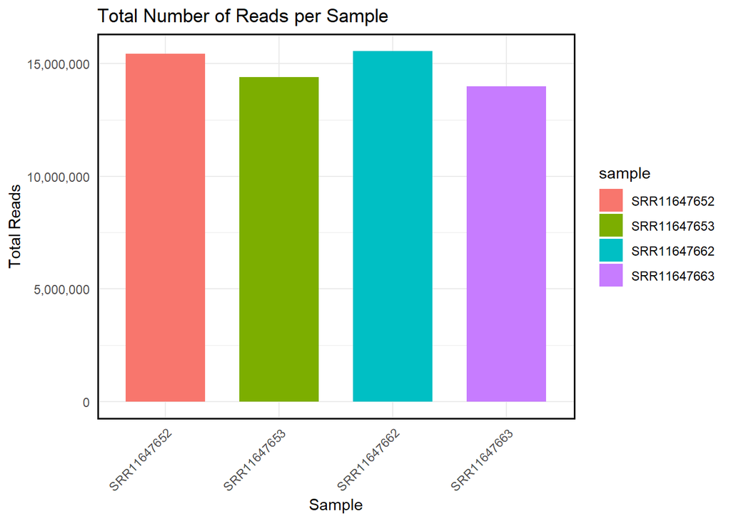

```r
reads_df <- data.frame(
  sample = c("SRR11647652", "SRR11647653",
             "SRR11647662", "SRR11647663"),
  total_reads = c(15430302, 14387697, 15552426, 13993364)
)

ggplot(reads_df, aes(x = sample, y = total_reads, fill = sample)) +
  geom_bar(stat = "identity", width = 0.7) +
  scale_y_continuous(labels = scales::comma) +
  labs(
    title = "Total Number of Reads per Sample",
    x = "Sample",
    y = "Total Reads"
  ) +
  theme_minimal() +
  theme(
    axis.text.x = element_text(angle = 45, hjust = 1),
    panel.border = element_rect(color = "black", fill = NA, linewidth = 1),
    legend.position = "right"
  )
```

```r
reads_df
```

```
       sample total_reads
1 SRR11647652    15430302
2 SRR11647653    14387697
3 SRR11647662    15552426
4 SRR11647663    13993364
```

```r
library(dplyr)
library(scales)
coverage_long <- bind_rows(
  SRR11647652 %>%
    select(chr, start, end, coverage) %>%
    mutate(sample_id = "SRR11647652"),

  SRR11647653 %>%
    select(chr, start, end, coverage) %>%
    mutate(sample_id = "SRR11647653"),

  SRR11647662 %>%
    select(chr, start, end, coverage) %>%
    mutate(sample_id = "SRR11647662"),

  SRR11647663 %>%
    select(chr, start, end, coverage) %>%
    mutate(sample_id = "SRR11647663")
)

coverage_long <- coverage_long %>%
  filter(!is.na(coverage))

# ggplot(coverage_long, aes(x = start, y = coverage)) +
#   geom_point(size = 0.15, alpha = 0.15, color = "#2C7FB8") +
#   geom_smooth(se = FALSE, linewidth = 0.7, color = "black") +
#   facet_wrap(~ sample_id, ncol = 2) +
#   scale_x_continuous(labels = comma) +
#   scale_y_continuous(labels = comma) +
#   coord_cartesian(ylim = c(0, 100)) +
#   labs(
#     title = "Coverage Across CpG Genomic Coordinates",
#     x = "CpG genomic position on chromosome 20",
#     y = "Coverage"
#   ) +
#   theme_minimal() +
#   theme(
#     panel.border = element_rect(color = "black", fill = NA, linewidth = 1),
#     strip.text = element_text(face = "bold"),
#     axis.text.x = element_text(angle = 45, hjust = 1)
#   )
```

```r
covered_cpgs <- sapply(list(SRR11647652, SRR11647653, SRR11647662, SRR11647663), function(df) {
  sum(df$coverage > 0, na.rm = TRUE)
})

names(covered_cpgs) <- c("SRR11647652", "SRR11647653", "SRR11647662", "SRR11647663")
covered_cpgs
```

```
SRR11647652 SRR11647653 SRR11647662 SRR11647663
    1469888     1460209     1477281     1469971
```

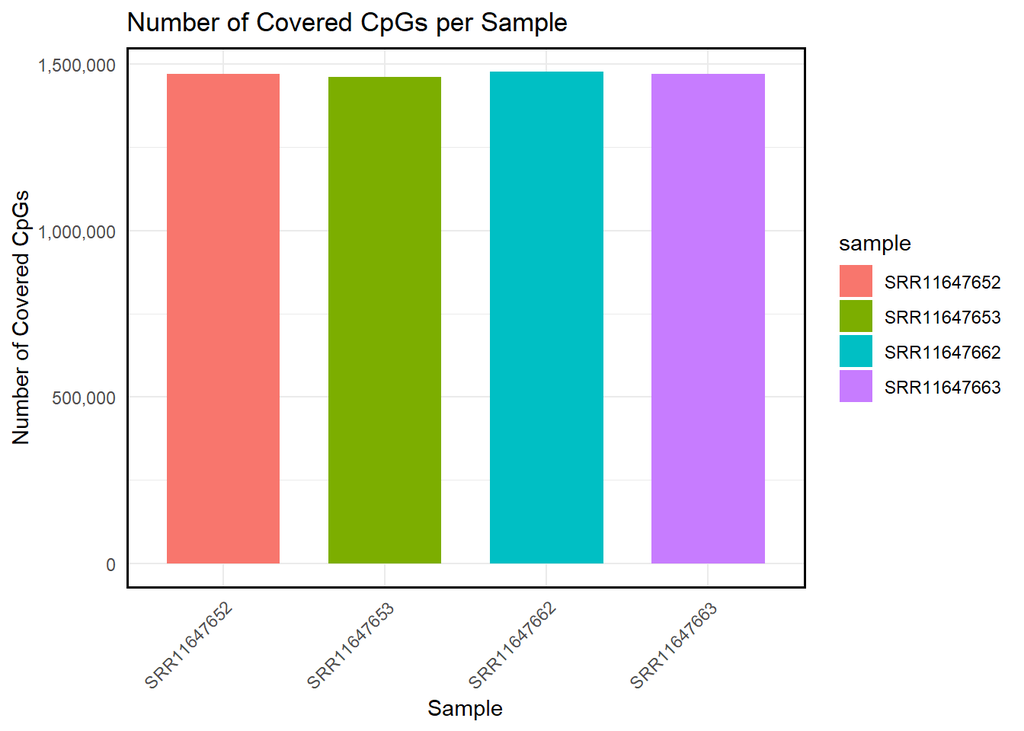

```r
covered_cpgs_df <- data.frame(
  sample = c("SRR11647652", "SRR11647653",
             "SRR11647662", "SRR11647663"),
  covered_cpgs = c(1469888, 1460209, 1477281, 1469971)
)

ggplot(covered_cpgs_df,
       aes(x = sample, y = covered_cpgs, fill = sample)) +
  geom_bar(stat = "identity", width = 0.7) +
  scale_y_continuous(labels = scales::comma) +
  labs(
    title = "Number of Covered CpGs per Sample",
    x = "Sample",
    y = "Number of Covered CpGs"
  ) +
  theme_minimal() +
  theme(
    axis.text.x = element_text(angle = 45, hjust = 1),
    panel.border = element_rect(color = "black",
                                fill = NA,
                                linewidth = 1),
    legend.position = "right"
  )
```

```r
# Calculate total CpGs and covered CpGs separately for each sample
covered_cpgs_df <- bind_rows(
  SRR11647652 %>%
    summarise(
      sample = "SRR11647652",
      total_cpgs = n_distinct(paste(chr, start, end)),
      covered_cpgs = n_distinct(paste(chr[coverage > 0], start[coverage > 0], end[coverage > 0]))
    ),

  SRR11647653 %>%
    summarise(
      sample = "SRR11647653",
      total_cpgs = n_distinct(paste(chr, start, end)),
      covered_cpgs = n_distinct(paste(chr[coverage > 0], start[coverage > 0], end[coverage > 0]))
    ),

  SRR11647662 %>%
    summarise(
      sample = "SRR11647662",
      total_cpgs = n_distinct(paste(chr, start, end)),
      covered_cpgs = n_distinct(paste(chr[coverage > 0], start[coverage > 0], end[coverage > 0]))
    ),

  SRR11647663 %>%
    summarise(
      sample = "SRR11647663",
      total_cpgs = n_distinct(paste(chr, start, end)),
      covered_cpgs = n_distinct(paste(chr[coverage > 0], start[coverage > 0], end[coverage > 0]))
    )
) %>%
  mutate(
    percent_covered = covered_cpgs / total_cpgs * 100,
    label = paste0(
      comma(covered_cpgs),
      " / ",
      comma(total_cpgs),
      "\n",
      round(percent_covered, 2), "%"
    )
  )

covered_cpgs_df
```

```
# A tibble: 4 × 5
  sample      total_cpgs covered_cpgs percent_covered label
  <chr>            <int>        <int>           <dbl> <chr>
1 SRR11647652    1469888      1469888             100 "1,469,888 / 1,469,888\n1…
2 SRR11647653    1460209      1460209             100 "1,460,209 / 1,460,209\n1…
3 SRR11647662    1477281      1477281             100 "1,477,281 / 1,477,281\n1…
4 SRR11647663    1469971      1469971             100 "1,469,971 / 1,469,971\n1…
```

Create a **correlation plot** (Pearson correlation) between samples using methylation levels. Provide the plot and explain what it shows.

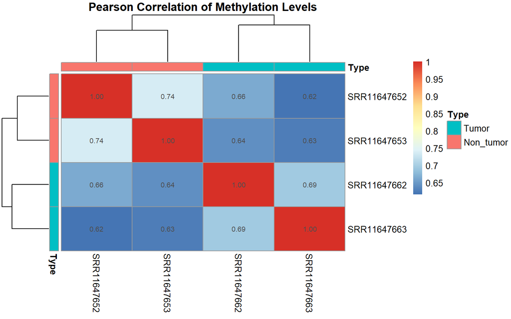

```r
# Make sure methylation_fraction exists in every sample
SRR11647652 <- SRR11647652 %>%
  mutate(methylation_fraction = methylation_percent / 100)

SRR11647653 <- SRR11647653 %>%
  mutate(methylation_fraction = methylation_percent / 100)

SRR11647662 <- SRR11647662 %>%
  mutate(methylation_fraction = methylation_percent / 100)

SRR11647663 <- SRR11647663 %>%
  mutate(methylation_fraction = methylation_percent / 100)


#Make sure all samples are aligned by genomic position:

merged <- SRR11647652 %>%
  dplyr::select(chr, start, methylation_fraction) %>%
  dplyr::rename(SRR11647652 = methylation_fraction) %>%
  dplyr::inner_join(
    SRR11647653 %>%
      dplyr::select(chr, start, methylation_fraction) %>%
      dplyr::rename(SRR11647653 = methylation_fraction),
    by = c("chr", "start")
  ) %>%
  dplyr::inner_join(
    SRR11647662 %>%
      dplyr::select(chr, start, methylation_fraction) %>%
      dplyr::rename(SRR11647662 = methylation_fraction),
    by = c("chr", "start")
  ) %>%
  dplyr::inner_join(
    SRR11647663 %>%
      dplyr::select(chr, start, methylation_fraction) %>%
      dplyr::rename(SRR11647663 = methylation_fraction),
    by = c("chr", "start")
  )

#Compute Pearson correlation matrix
cor_matrix <- cor(merged[, -c(1,2)], method = "pearson", use = "complete.obs")

#Plot correlation heatmap
library(pheatmap)

annotation <- data.frame(
  Type = c("Non_tumor", "Non_tumor", "Tumor", "Tumor")
)

rownames(annotation) <- c("SRR11647652", "SRR11647653",
                         "SRR11647662", "SRR11647663")

ann_colors <- list(
  Type = c(
    Tumor = "#00BFC4",
    Non_tumor = "#F8766D"
  )
)

pheatmap(cor_matrix,
         display_numbers = TRUE,
         main = "Pearson Correlation of Methylation Levels",
         annotation_col = annotation,
         annotation_row = annotation,
         annotation_colors = ann_colors)
```

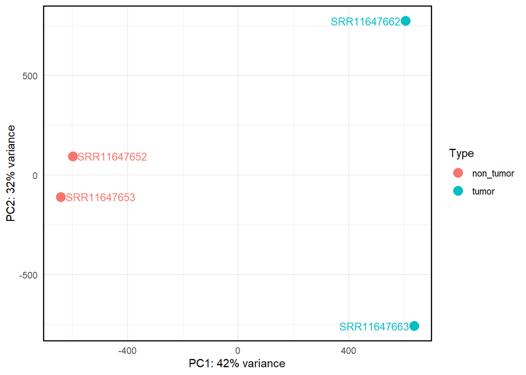

```r
SRR11647652 <- SRR11647652 %>%
  mutate(site = paste(chr, start, end, sep = "_"),
         SRR11647652 = methylation_percent)

SRR11647653 <- SRR11647653 %>%
  mutate(site = paste(chr, start, end, sep = "_"),
         SRR11647653 = methylation_percent)

SRR11647662 <- SRR11647662 %>%
  mutate(site = paste(chr, start, end, sep = "_"),
         SRR11647662 = methylation_percent)

SRR11647663 <- SRR11647663 %>%
  mutate(site = paste(chr, start, end, sep = "_"),
         SRR11647663 = methylation_percent)

meth_matrix <- SRR11647652 %>%
  select(site, SRR11647652) %>%
  inner_join(SRR11647653 %>% select(site, SRR11647653), by = "site") %>%
  inner_join(SRR11647662 %>% select(site, SRR11647662), by = "site") %>%
  inner_join(SRR11647663 %>% select(site, SRR11647663), by = "site")

mat <- meth_matrix %>%
  select(-site) %>%
  as.matrix()

rownames(mat) <- meth_matrix$site

mat <- mat[apply(mat, 1, var) != 0, ]

pca <- prcomp(t(mat), scale. = TRUE)

pca_df <- as.data.frame(pca$x)

pca_df$sample <- c("SRR11647652", "SRR11647653", "SRR11647662", "SRR11647663")

pca_df$Type <- c("non_tumor", "non_tumor", "tumor", "tumor")

percentVar <- round(100 * (pca$sdev^2 / sum(pca$sdev^2)))

library(ggrepel)
ggplot(pca_df, aes(x = PC1, y = PC2, color = Type, label = sample)) +
  geom_point(size = 4) +
  geom_text_repel(size = 3.5) +
  xlab(paste0("PC1: ", percentVar[1], "% variance")) +
  ylab(paste0("PC2: ", percentVar[2], "% variance")) +
  labs(color = "Type") +
  scale_color_manual(values = c(
    "non_tumor" = "#F8766D",
    "tumor" = "#00BFC4"
  )) +
  theme_minimal() +
  theme(
    panel.border = element_rect(color = "black", fill = NA, linewidth = 1),
    legend.position = "right"
  )
```

Rerun PCA with different filtering (≥5x, ≥15x, ≥20x coverage). How does filtering affect sample clustering? Create a comparison figure and explain it.

```r
run_pca_filter <- function(cov_threshold) {

  f52 <- SRR11647652 %>% filter(coverage >= cov_threshold)
  f53 <- SRR11647653 %>% filter(coverage >= cov_threshold)
  f62 <- SRR11647662 %>% filter(coverage >= cov_threshold)
  f63 <- SRR11647663 %>% filter(coverage >= cov_threshold)

  m52 <- f52 %>% mutate(site = paste(chr, start, end),
                       SRR11647652 = methylation_percent)
  m53 <- f53 %>% mutate(site = paste(chr, start, end),
                       SRR11647653 = methylation_percent)
  m62 <- f62 %>% mutate(site = paste(chr, start, end),
                       SRR11647662 = methylation_percent)
  m63 <- f63 %>% mutate(site = paste(chr, start, end),
                       SRR11647663 = methylation_percent)

  mat <- m52 %>%
    select(site, SRR11647652) %>%
    inner_join(m53 %>% select(site, SRR11647653), by="site") %>%
    inner_join(m62 %>% select(site, SRR11647662), by="site") %>%
    inner_join(m63 %>% select(site, SRR11647663), by="site")

  mat <- mat %>% select(-site) %>% as.matrix()
  rownames(mat) <- m52$site[match(rownames(mat), m52$site)]

  mat <- mat[apply(mat, 1, var) != 0, ]

  pca <- prcomp(t(mat), scale. = TRUE)

  df <- as.data.frame(pca$x)
  df$sample <- c("SRR11647652","SRR11647653","SRR11647662","SRR11647663")
  df$Type <- c("non_tumor","non_tumor","tumor","tumor")
  df$filter <- paste0("≥", cov_threshold, "x")

  return(df)
}
```

```r
pca5  <- run_pca_filter(5)
pca15 <- run_pca_filter(15)
pca20 <- run_pca_filter(20)

all_pca <- bind_rows(pca5, pca15, pca20)
all_pca$filter <- factor(all_pca$filter,
                         levels = c("≥5x", "≥15x", "≥20x"))
```

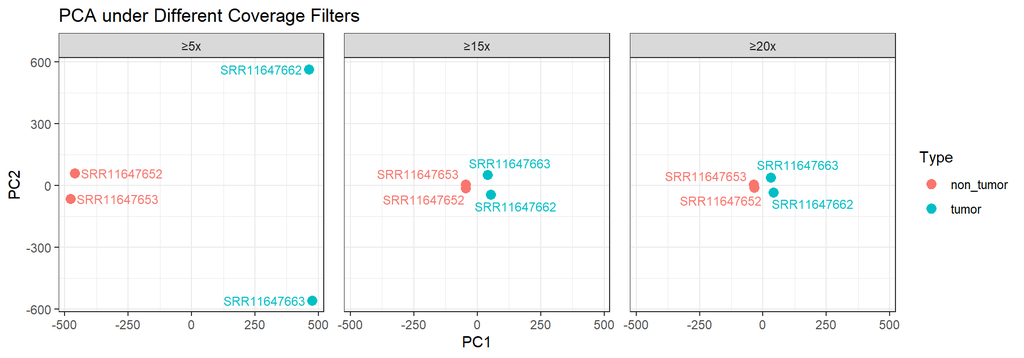

```r
ggplot(all_pca, aes(PC1, PC2, color = Type, label = sample)) +
  geom_point(size = 3) +
  geom_text_repel(size = 3) +
  facet_wrap(~filter) +
  theme_bw() +
  scale_color_manual(values = c("non_tumor"="#F8766D","tumor"="#00BFC4")) +
  labs(title = "PCA under Different Coverage Filters",
       x = "PC1",
       y = "PC2") +
  theme(
    panel.spacing = unit(0.5, "cm")   # 👈 spacing between panels
  )
```

Visualize **coverage distribution** across samples. Discuss potential biases (e.g., uneven coverage, low coverage CpGs).

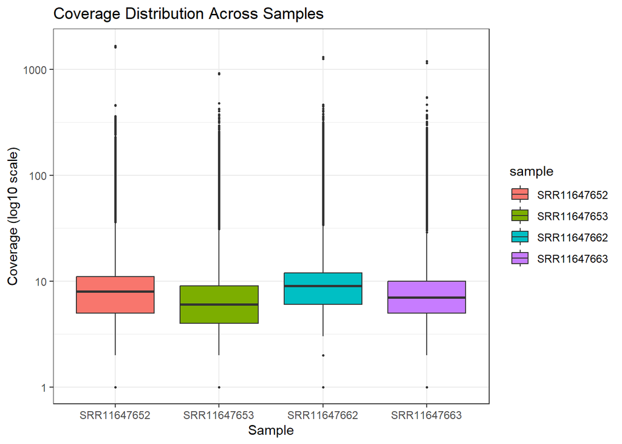

```r
cov_data <- bind_rows(
  SRR11647652 %>% select(coverage) %>% mutate(sample = "SRR11647652"),
  SRR11647653 %>% select(coverage) %>% mutate(sample = "SRR11647653"),
  SRR11647662 %>% select(coverage) %>% mutate(sample = "SRR11647662"),
  SRR11647663 %>% select(coverage) %>% mutate(sample = "SRR11647663")
)

ggplot(cov_data, aes(x = sample, y = coverage, fill = sample)) +
  geom_boxplot(outlier.size = 0.5) +
  scale_y_log10() +
  theme_bw() +
  labs(
    title = "Coverage Distribution Across Samples",
    x = "Sample",
    y = "Coverage (log10 scale)"
  )
```

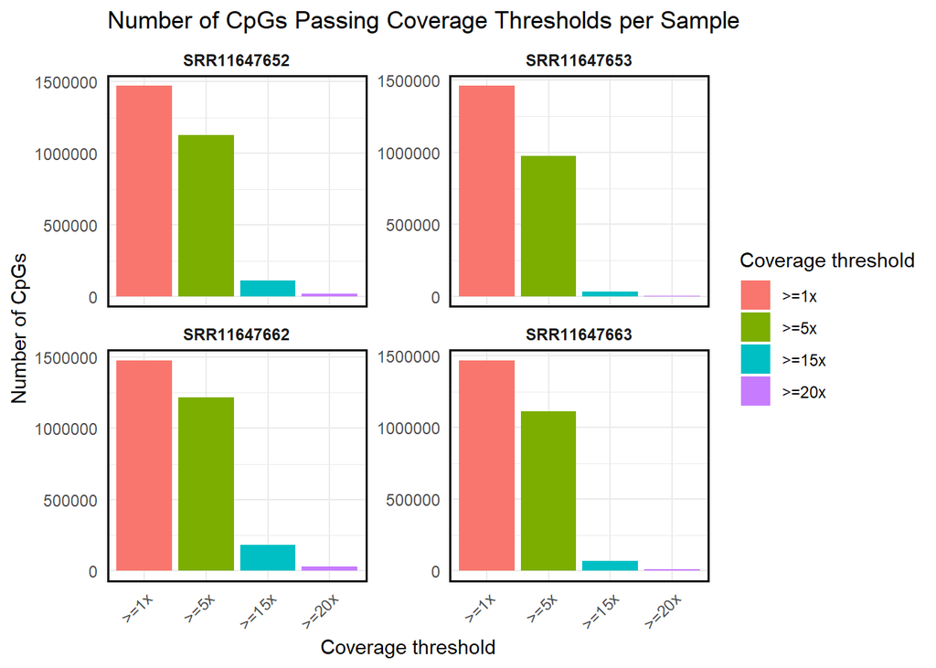

```r
library(dplyr)
library(ggplot2)
library(scales)

coverage_long <- bind_rows(
  SRR11647652 %>%
    select(chr, start, end, coverage) %>%
    mutate(sample_id = "SRR11647652"),

  SRR11647653 %>%
    select(chr, start, end, coverage) %>%
    mutate(sample_id = "SRR11647653"),

  SRR11647662 %>%
    select(chr, start, end, coverage) %>%
    mutate(sample_id = "SRR11647662"),

  SRR11647663 %>%
    select(chr, start, end, coverage) %>%
    mutate(sample_id = "SRR11647663")
)

coverage_long <- coverage_long %>%
  filter(!is.na(coverage))

# ggplot(coverage_long, aes(x = start, y = coverage)) +
#   geom_point(size = 0.15, alpha = 0.15, color = "#2C7FB8") +
#   geom_smooth(se = FALSE, linewidth = 0.7, color = "black") +
#   facet_wrap(~ sample_id, ncol = 2) +
#   scale_x_continuous(labels = comma) +
#   scale_y_continuous(labels = comma) +
#   coord_cartesian(ylim = c(0, 100)) +
#   labs(
#     title = "Coverage Across CpG Genomic Coordinates",
#     x = "CpG genomic position on chromosome 20",
#     y = "Coverage"
#   ) +
#   theme_minimal() +
#   theme(
#     panel.border = element_rect(color = "black", fill = NA, linewidth = 1),
#     strip.text = element_text(face = "bold"),
#     axis.text.x = element_text(angle = 45, hjust = 1)
#   )

coverage_thresholds <- coverage_long %>%
  group_by(sample_id) %>%
  summarise(
    `>=1x`  = sum(coverage >= 1, na.rm = TRUE),
    `>=5x`  = sum(coverage >= 5, na.rm = TRUE),
    `>=15x` = sum(coverage >= 15, na.rm = TRUE),
    `>=20x` = sum(coverage >= 20, na.rm = TRUE),
    .groups = "drop"
  ) %>%
  pivot_longer(
    cols = starts_with(">="),
    names_to = "Coverage_threshold",
    values_to = "Number_of_CpGs"
  ) %>%
  mutate(
    Coverage_threshold = factor(
      Coverage_threshold,
      levels = c(">=1x", ">=5x", ">=15x", ">=20x")
    )
  )

ggplot(
  coverage_thresholds,
  aes(
    x = Coverage_threshold,
    y = Number_of_CpGs,
    fill = Coverage_threshold
  )
) +
  geom_bar(stat = "identity") +
  facet_wrap(~ sample_id, ncol = 2, scales = "free_y") +
  labs(
    title = "Number of CpGs Passing Coverage Thresholds per Sample",
    x = "Coverage threshold",
    y = "Number of CpGs",
    fill = "Coverage threshold"
  ) +
  theme_minimal() +
  theme(
    panel.border = element_rect(color = "black", fill = NA, linewidth = 1),
    strip.text = element_text(face = "bold"),
    axis.text.x = element_text(angle = 45, hjust = 1)
  )
```

# DMC calling

```r
sample_info <- data.frame(
  sample_id = c(
    "SRR11647662",
    "SRR11647663",
    "SRR11647652",
    "SRR11647653"
  ),
  condition = c(
    "tumor",
    "tumor",
    "healthy",
    "healthy"
  ),
  stringsAsFactors = FALSE
)

sample_info
```

```
    sample_id condition
1 SRR11647662     tumor
2 SRR11647663     tumor
3 SRR11647652   healthy
4 SRR11647653   healthy
```

```r
# Task 1: Perform differentially methylated cytosine (DMC) analysis between your conditions.
# ============================================================
# Create methylation_dt and coverage_dt from your R file objects
# ============================================================
library(data.table)

# Add a shared CpG ID to each sample
SRR11647652 <- SRR11647652 %>%
  mutate(cpg_id = paste(chr, start, end, sep = "_"))

SRR11647653 <- SRR11647653 %>%
  mutate(cpg_id = paste(chr, start, end, sep = "_"))

SRR11647662 <- SRR11647662 %>%
  mutate(cpg_id = paste(chr, start, end, sep = "_"))

SRR11647663 <- SRR11647663 %>%
  mutate(cpg_id = paste(chr, start, end, sep = "_"))

# Build methylation table using methylation fraction
methylation_dt <- SRR11647652 %>%
  select(cpg_id, chr, position = start, SRR11647652 = methylation_fraction) %>%
  inner_join(
    SRR11647653 %>% select(cpg_id, SRR11647653 = methylation_fraction),
    by = "cpg_id"
  ) %>%
  inner_join(
    SRR11647662 %>% select(cpg_id, SRR11647662 = methylation_fraction),
    by = "cpg_id"
  ) %>%
  inner_join(
    SRR11647663 %>% select(cpg_id, SRR11647663 = methylation_fraction),
    by = "cpg_id"
  )
nrow(SRR11647652)
```

```
[1] 1469888
```

```r
nrow(methylation_dt)
```

```
[1] 1402155
```

```r
# Build coverage table using coverage
coverage_dt <- SRR11647652 %>%
  select(cpg_id, chr, position = start, SRR11647652 = coverage) %>%
  inner_join(
    SRR11647653 %>% select(cpg_id, SRR11647653 = coverage),
    by = "cpg_id"
  ) %>%
  inner_join(
    SRR11647662 %>% select(cpg_id, SRR11647662 = coverage),
    by = "cpg_id"
  ) %>%
  inner_join(
    SRR11647663 %>% select(cpg_id, SRR11647663 = coverage),
    by = "cpg_id"
  )

# Convert to data.table
setDT(methylation_dt)
setDT(coverage_dt)
```

```r
# Create BSseq object
library(pacman)
sample_cols <- names(methylation_dt)[!names(methylation_dt) %in% c("cpg_id", "chr", "position")]

chr <- methylation_dt$chr
pos <- methylation_dt$position

#Create empty matrices for methylated reads and coverage
#M_matrix   = methylated read counts
#Cov_matrix = total coverage counts
M_matrix <- matrix(NA, nrow = nrow(methylation_dt), ncol = length(sample_cols))
Cov_matrix <- matrix(NA, nrow = nrow(methylation_dt), ncol = length(sample_cols))

#Fill the matrices sample by sample
  for(i in 1:length(sample_cols)) {
    sample <- sample_cols[i]

    meth <- methylation_dt[[sample]]
    cov <- coverage_dt[[sample]]

    M_matrix[, i] <- round(meth * cov, 0) #converts methylation fractions into approximate methylated-read counts.

    Cov_matrix[, i] <- cov #stores total coverage.

    M_matrix[is.na(M_matrix[, i]), i] <- 0
    Cov_matrix[is.na(Cov_matrix[, i]), i] <- 0  #replace missing values with 0
  }

colnames(M_matrix) <- sample_cols
colnames(Cov_matrix) <- sample_cols #This gives the matrices proper sample names.

#Create a BSseq object
library(bsseq)
BS <- BSseq(chr = chr,
            pos = pos,
            M = M_matrix,
            Cov = Cov_matrix,
            sampleNames = sample_cols)

pData(BS) <- sample_info
rownames(pData(BS)) <- sample_info$sample_id
saveRDS(BS, "bsseq_object.RDS")

# Define comparison
group1_samples <- c("SRR11647652", "SRR11647653")  # healthy / normal
group2_samples <- c("SRR11647662", "SRR11647663")  # tumor

selected_samples <- c(group1_samples, group2_samples)

# Check that samples are present
selected_samples %in% sampleNames(BS)
```

```
[1] TRUE TRUE TRUE TRUE
```

```r
# Filtering BS data. What can happen if we skip this?
#Filter low-coverage CpGs
cov_matrix <- getCoverage(BS)
samples_covered <- rowSums(
  cov_matrix[, selected_samples] >= 10,
  na.rm = TRUE
) #For every CpG, this counts how many selected samples have coverage at least 10

keep_cpgs <- samples_covered >= 2 #keeps CpGs where at least 2 samples have coverage >= 10

BS_filtered <- BS[keep_cpgs] #subsets the BSseq object to only those CpGs.
saveRDS(BS_filtered, "BS_filtered.RDS")

library(DSS)
# Run DMC testing with DSS
# This runs differential methylation testing at individual CpG sites.
# DMLtest() compares methylation between groups
dmlTest <- DMLtest(BS_filtered,
                  group1 = group1_samples,
                  group2 = group2_samples,
                  ncores = 1,
                  smoothing = FALSE) #means DSS tests each CpG without smoothing methylation values across neighboring CpGs.
```

```
Estimating dispersion for each CpG site, this will take a while ...
```

```r
saveRDS(dmlTest, "dss_dmlTest_result.RDS")


library(data.table)

# Convert DSS result to data.table
dml_dt <- as.data.table(dmlTest)


# -------------------------------
# Task 2: Save two lists of DMCs
# -------------------------------

# Case 1: only statistical significance
# Adjusted p-value / FDR threshold only
# It does not require the methylation difference to be large.
dmcs_fdr_only <- dml_dt[
  fdr < 0.05
]

# Case 2: statistical significance + methylation difference threshold
# FDR < 0.05 and methylation difference at least 10 percentage points
dmcs_fdr_delta <- dml_dt[
  fdr < 0.05 & abs(diff) >= 0.10
]

# Save both DMC lists
fwrite(dmcs_fdr_only, "DMCs_FDR_0.05_only.csv")
fwrite(dmcs_fdr_delta, "DMCs_FDR_0.05_delta_0.10.csv")


# -----------------------------------------------
# Task 3: Report total number of DMCs in both cases
# -----------------------------------------------

# Because group1 = healthy and group2 = tumor:
# diff = healthy - tumor
#
# Therefore:
# diff < 0 = hypermethylated in tumor
# diff > 0 = hypomethylated in tumor

dmc_summary <- data.frame(
  Case = c(
    "FDR < 0.05 only",
    "FDR < 0.05 and |diff| >= 0.10"
  ),
  Total_DMCs = c(
    nrow(dmcs_fdr_only),
    nrow(dmcs_fdr_delta)
  ),
  Tumor_hypermethylated = c(
    sum(dmcs_fdr_only$diff < 0, na.rm = TRUE),
    sum(dmcs_fdr_delta$diff < 0, na.rm = TRUE)
  ),
  Tumor_hypomethylated = c(
    sum(dmcs_fdr_only$diff > 0, na.rm = TRUE),
    sum(dmcs_fdr_delta$diff > 0, na.rm = TRUE)
  )
)

dmc_summary
```

```
                           Case Total_DMCs Tumor_hypermethylated
1               FDR < 0.05 only      33454                 32734
2 FDR < 0.05 and |diff| >= 0.10      33454                 32734
  Tumor_hypomethylated
1                  720
2                  720
```

Using a chromosome you like (or several), perform DMC calling using an R package you like (you can use DSS that we used) and using the Wilcoxon test. Create Venn diagram of overlap between the methods. Table comparing the number of DMCs, mean effect size. Which method is more conservative? Why?

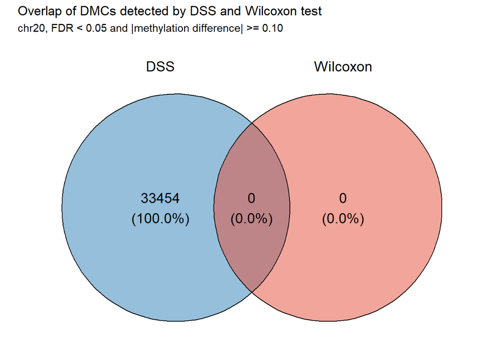

```r
library(data.table)
library(matrixTests)
library(ggvenn)
library(knitr)

# ------------------------------------------------------------
# Groups from your data
# ------------------------------------------------------------
non_tumour_samples <- c("SRR11647652", "SRR11647653")
tumour_samples     <- c("SRR11647662", "SRR11647663")

# Your methylation_dt columns are:
# cpg_id, chr, position, SRR11647652, SRR11647653, SRR11647662, SRR11647663
sample_cols <- c(non_tumour_samples, tumour_samples)

# ------------------------------------------------------------
# Use the same CpGs as DSS filtering
# keep_cpgs was created before DSS:
# keep_cpgs <- samples_covered >= 2
# ------------------------------------------------------------
meth_filtered <- methylation_dt[keep_cpgs, ]

# Methylation matrix for Wilcoxon
meth_wilcox <- as.matrix(meth_filtered[, ..sample_cols])
rownames(meth_wilcox) <- meth_filtered$cpg_id
mode(meth_wilcox) <- "numeric"

# ------------------------------------------------------------
# Wilcoxon test
# ------------------------------------------------------------
wilcox_test <- row_wilcoxon_twosample(
  meth_wilcox[, tumour_samples, drop = FALSE],
  meth_wilcox[, non_tumour_samples, drop = FALSE]
)

wilcox_results <- data.table(
  cpg_id = meth_filtered$cpg_id,
  chr = meth_filtered$chr,
  position = meth_filtered$position,

  # Difference is tumor - non-tumor
  # diff > 0 = hypermethylated in tumor
  # diff < 0 = hypomethylated in tumor
  diff = rowMeans(meth_wilcox[, tumour_samples, drop = FALSE], na.rm = TRUE) -
         rowMeans(meth_wilcox[, non_tumour_samples, drop = FALSE], na.rm = TRUE),

  pval = wilcox_test$pvalue
)

wilcox_results[, fdr := p.adjust(pval, method = "BH")]

wilcox_dmcs <- wilcox_results[
  fdr < 0.05 & abs(diff) >= 0.10
]

# ------------------------------------------------------------
# DSS DMCs
# ------------------------------------------------------------
dss_dt <- as.data.table(dmlTest)

# DSS output has columns chr and pos.
# Your methylation_dt cpg_id format is chr_start_end,
# but DSS only stores chr and pos.
# So for overlap, use chr:position in BOTH methods.
dss_dt[, cpg_id := paste0(chr, ":", pos)]

dss_dmcs <- dss_dt[
  fdr < 0.05 & abs(diff) >= 0.10
]

# Convert Wilcoxon cpg_id to same format as DSS
wilcox_results[, cpg_id := paste0(chr, ":", position)]

wilcox_dmcs <- wilcox_results[
  fdr < 0.05 & abs(diff) >= 0.10
]

# ------------------------------------------------------------
# Venn diagram
# ------------------------------------------------------------
venn_list <- list(
  DSS = dss_dmcs$cpg_id,
  Wilcoxon = wilcox_dmcs$cpg_id
)

ggvenn(
  venn_list,
  fill_color = c("#2C7FB8", "#E64B35"),
  stroke_size = 0.5,
  set_name_size = 5,
  text_size = 5
) +
  labs(
    title = "Overlap of DMCs detected by DSS and Wilcoxon test",
    subtitle = "chr20, FDR < 0.05 and |methylation difference| >= 0.10"
  )
```

```r
# ------------------------------------------------------------
# Table: number of DMCs and mean effect size
# ------------------------------------------------------------
overlap_ids <- intersect(dss_dmcs$cpg_id, wilcox_dmcs$cpg_id)

dmc_method_table <- data.frame(
  Method = c("DSS", "Wilcoxon", "Overlap"),
  Number_of_DMCs = c(
    nrow(dss_dmcs),
    nrow(wilcox_dmcs),
    length(overlap_ids)
  ),
  Mean_abs_effect_size = c(
    mean(abs(dss_dmcs$diff), na.rm = TRUE),
    mean(abs(wilcox_dmcs$diff), na.rm = TRUE),
    NA
  )
)

# Optional: print the table too
dmc_method_table
```

```
    Method Number_of_DMCs Mean_abs_effect_size
1      DSS          33454            0.5311089
2 Wilcoxon              0                  NaN
3  Overlap              0                   NA
```

Threshold exploration. Test 4 combinations:

- p<0.05, Δβ>0.1
- p<0.01, Δβ>0.1
- p<0.05, Δβ>0.2
- p<0.01, Δβ>0.2

Create a comparison table. Plot: number of DMCs vs threshold stringency. Recommend best threshold for your data

```r
library(data.table)
library(ggplot2)
library(scales)
library(knitr)

# Convert DSS result to data.table
dss_dt <- as.data.table(dmlTest)

# Threshold combinations using FDR-adjusted p-value
threshold_results <- data.frame(
  Threshold = c(
    "FDR < 0.05, |Δβ| ≥ 0.10",
    "FDR < 0.01, |Δβ| ≥ 0.10",
    "FDR < 0.05, |Δβ| ≥ 0.20",
    "FDR < 0.01, |Δβ| ≥ 0.20"
  ),
  DMC_count = c(
    nrow(dss_dt[fdr < 0.05 & abs(diff) >= 0.10]),
    nrow(dss_dt[fdr < 0.01 & abs(diff) >= 0.10]),
    nrow(dss_dt[fdr < 0.05 & abs(diff) >= 0.20]),
    nrow(dss_dt[fdr < 0.01 & abs(diff) >= 0.20])
  ),
  Mean_abs_effect_size = c(
    mean(abs(dss_dt[fdr < 0.05 & abs(diff) >= 0.10]$diff), na.rm = TRUE),
    mean(abs(dss_dt[fdr < 0.01 & abs(diff) >= 0.10]$diff), na.rm = TRUE),
    mean(abs(dss_dt[fdr < 0.05 & abs(diff) >= 0.20]$diff), na.rm = TRUE),
    mean(abs(dss_dt[fdr < 0.01 & abs(diff) >= 0.20]$diff), na.rm = TRUE)
  )
)

# Keep threshold order
threshold_results$Threshold <- factor(
  threshold_results$Threshold,
  levels = threshold_results$Threshold
)

threshold_results
```

```
                Threshold DMC_count Mean_abs_effect_size
1 FDR < 0.05, |Δβ| ≥ 0.10     33454            0.5311089
2 FDR < 0.01, |Δβ| ≥ 0.10     14588            0.5907961
3 FDR < 0.05, |Δβ| ≥ 0.20     33454            0.5311089
4 FDR < 0.01, |Δβ| ≥ 0.20     14588            0.5907961
```

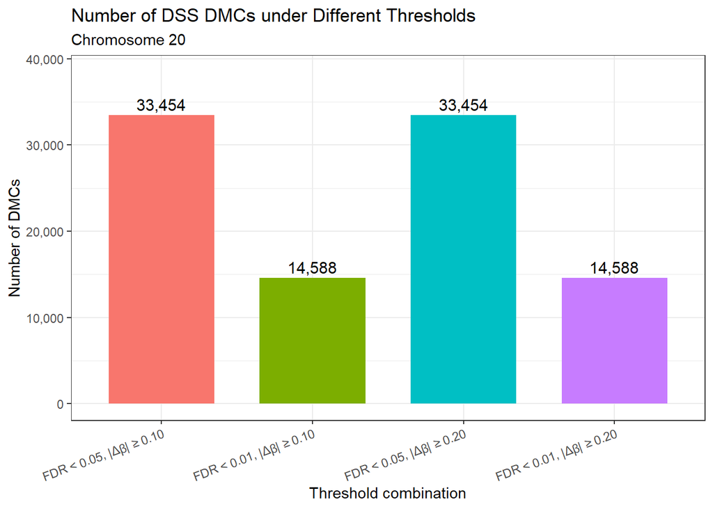

```r
# Plot
ggplot(threshold_results, aes(x = Threshold, y = DMC_count, fill = Threshold)) +
  geom_col(width = 0.7, show.legend = FALSE) +
  geom_text(
    aes(label = scales::comma(DMC_count)),
    vjust = -0.4,
    size = 4
  ) +
  scale_y_continuous(
    labels = scales::comma,
    limits = c(0, max(threshold_results$DMC_count) * 1.15)
  ) +
  labs(
    title = "Number of DSS DMCs under Different Thresholds",
    subtitle = "Chromosome 20",
    x = "Threshold combination",
    y = "Number of DMCs"
  ) +
  theme_bw() +
  theme(
    axis.text.x = element_text(angle = 20, hjust = 1)
  )
```

```r
threshold_results
```

```
                Threshold DMC_count Mean_abs_effect_size
1 FDR < 0.05, |Δβ| ≥ 0.10     33454            0.5311089
2 FDR < 0.01, |Δβ| ≥ 0.10     14588            0.5907961
3 FDR < 0.05, |Δβ| ≥ 0.20     33454            0.5311089
4 FDR < 0.01, |Δβ| ≥ 0.20     14588            0.5907961
```

Create a **volcano plot** for DMCs. Explain the relationship between methylation difference and statistical significance.

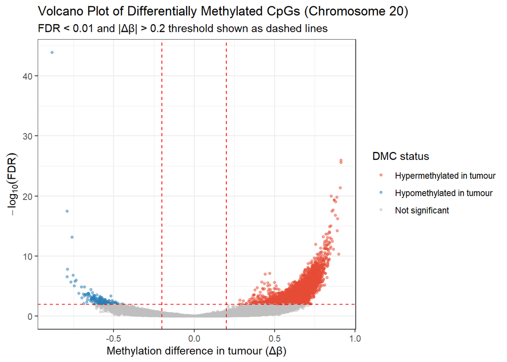

```r
library(data.table)
library(ggplot2)
library(scales)

# ------------------------------------------------------------
# DSS results from your data
# ------------------------------------------------------------

dss_dt <- as.data.table(dmlTest)

# Remove rows with missing p-values or FDR values
dss_dt <- dss_dt[
  !is.na(pval) & !is.na(fdr) & !is.na(diff)
]

# ------------------------------------------------------------
# Direction of methylation difference
# ------------------------------------------------------------
# DSS diff is usually group1 - group2.
# In your DSS setup:
# group1 = non-tumour / healthy
# group2 = tumour
#
# Therefore:
# diff > 0 means higher methylation in non-tumour
# diff < 0 means higher methylation in tumour
#
# Flip diff so positive = higher methylation in tumour.

dss_dt[, tumour_diff := -diff]

# ------------------------------------------------------------
# Define DMC status using FDR
# ------------------------------------------------------------

dss_dt[, status := fifelse(
  fdr < 0.01 & tumour_diff >= 0.20,
  "Hypermethylated in tumour",
  fifelse(
    fdr < 0.01 & tumour_diff <= -0.20,
    "Hypomethylated in tumour",
    "Not significant"
  )
)]

# Set order for legend
dss_dt[, status := factor(
  status,
  levels = c(
    "Hypermethylated in tumour",
    "Hypomethylated in tumour",
    "Not significant"
  )
)]

# ------------------------------------------------------------
# Volcano plot
# ------------------------------------------------------------

ggplot(
  dss_dt,
  aes(
    x = tumour_diff,
    y = -log10(fdr),
    color = status
  )
) +
  geom_point(alpha = 0.5, size = 1) +
  geom_vline(
    xintercept = c(-0.2, 0.2),
    linetype = "dashed",
    color = "red"
  ) +
  geom_hline(
    yintercept = -log10(0.01),
    linetype = "dashed",
    color = "red"
  ) +
  scale_color_manual(
    values = c(
      "Hypermethylated in tumour" = "#E64B35",
      "Hypomethylated in tumour" = "#2C7FB8",
      "Not significant" = "grey75"
    )
  ) +
  labs(
    title = "Volcano Plot of Differentially Methylated CpGs (Chromosome 20)",
    subtitle = "FDR < 0.01 and |Δβ| > 0.2 threshold shown as dashed lines",
    x = "Methylation difference in tumour (Δβ)",
    y = expression(-log[10](FDR)),
    color = "DMC status"
  ) +
  theme_bw()
```

Create an **MA plot (or equivalent)**:

- x-axis: average methylation level,
- y-axis: methylation difference.

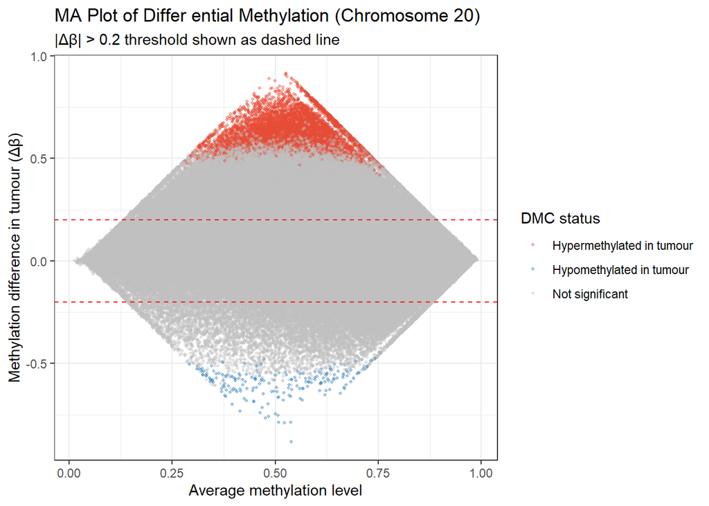

```r
# ------------------------------------------------------------
# MA plot data from DSS
# ------------------------------------------------------------

# ------------------------------------------------------------
# Direction of methylation difference
# ------------------------------------------------------------
# DSS diff = group1 - group2
# In your analysis:
# group1 = non-tumour / healthy
# group2 = tumour
#
# Therefore:
# diff > 0 means higher methylation in non-tumour
# diff < 0 means higher methylation in tumour

# Average methylation across non-tumour and tumour groups
dss_dt[, mean_methylation := (mu1 + mu2) / 2]

# ------------------------------------------------------------
# Define DMC status
# ------------------------------------------------------------

dss_dt[, status := fifelse(
  fdr < 0.01 & tumour_diff >= 0.2,
  "Hypermethylated in tumour",
  fifelse(
    fdr < 0.01 & tumour_diff <= -0.2,
    "Hypomethylated in tumour",
    "Not significant"
  )
)]

dss_dt[, status := factor(
  status,
  levels = c(
    "Hypermethylated in tumour",
    "Hypomethylated in tumour",
    "Not significant"
  )
)]

# ------------------------------------------------------------
# MA plot
# ------------------------------------------------------------

ggplot(
  dss_dt,
  aes(
    x = mean_methylation,
    y = tumour_diff,
    color = status
  )
) +
  geom_point(alpha = 0.4, size = 0.8) +
  geom_hline(
    yintercept = c(-0.2, 0.2),
    linetype = "dashed",
    color = "red"
  ) +
  scale_color_manual(
    values = c(
      "Hypermethylated in tumour" = "#E64B35",
      "Hypomethylated in tumour" = "#2C7FB8",
      "Not significant" = "grey75"
    )
  ) +
  labs(
    title = "MA Plot of Differ ential Methylation (Chromosome 20)",
    subtitle = "|Δβ| > 0.2 threshold shown as dashed line",
    x = "Average methylation level",
    y = "Methylation difference in tumour (Δβ)",
    color = "DMC status"
  ) +
  theme_bw()
```

Extract promoter DMCs only. Compare with all DMCs: do you see different enrichment patterns? Are promoter DMCs more biologically meaningful?

```r
library(knitr)
library(scales)
library(GenomicRanges)
library(annotatr)
library(TxDb.Hsapiens.UCSC.hg38.knownGene)
library(org.Hs.eg.db)
```

```r
library(AnnotationDbi)

# ------------------------------------------------------------
# 1. Prepare DSS results
# ------------------------------------------------------------

dss_dt <- as.data.table(dmlTest)

dss_dt <- dss_dt %>% filter( fdr < 0.01, abs(diff) >= 0.20 )

dss_dt <- dss_dt[
  !is.na(pval) &
    !is.na(fdr) &
    !is.na(diff) &
    !is.na(chr) &
    !is.na(pos)
]

# DSS diff = group1 - group2
# group1 = non-tumour / healthy
# group2 = tumour
# Flip diff so positive = higher methylation in tumour

dss_dt[, tumour_diff := -diff]

dmcs_dt <- dss_dt[
  fdr < 0.01 & abs(tumour_diff) >= 0.20
]

dmcs_dt[, dmc_index := .I]
dmcs_dt[, cpg_id := paste0(chr, ":", pos)]

dmcs_dt[, direction := fifelse(
  tumour_diff > 0,
  "Hypermethylated in tumour",
  "Hypomethylated in tumour"
)]

# ------------------------------------------------------------
# 2. Convert DMCs to GRanges
# ------------------------------------------------------------

dmcs_gr <- GRanges(
  seqnames = dmcs_dt$chr,
  ranges = IRanges(
    start = dmcs_dt$pos,
    width = 1
  ),
  dmc_index = dmcs_dt$dmc_index,
  cpg_id = dmcs_dt$cpg_id,
  diff = dmcs_dt$diff,
  tumour_diff = dmcs_dt$tumour_diff,
  pval = dmcs_dt$pval,
  fdr = dmcs_dt$fdr
)

# ------------------------------------------------------------
# 3. Build hg38 annotations directly, no RDS files
# ------------------------------------------------------------

annots <- c(
  "hg38_cpgs",
  "hg38_genes_promoters",
  "hg38_genes_5UTRs",
  "hg38_genes_exons",
  "hg38_genes_introns",
  "hg38_genes_3UTRs",
  "hg38_genes_intergenic"
)

annotations <- build_annotations(
  genome = "hg38",
  annotations = annots
)
```

```
Building promoters...
```

```
Building 1to5kb upstream of TSS...
```

```
Building intergenic...
```

```
Building 5UTRs...
```

```
Building 3UTRs...
```

```
Building exons...
```

```
Building introns...
```

```
Building CpG islands...
```

```
Building CpG shores...
```

```
Building CpG shelves...
```

```
Building inter-CpG-islands...
```

```r
# ------------------------------------------------------------
# 4. Annotate DMCs with genomic features
# ------------------------------------------------------------

dmcs_annotated <- annotate_regions(
  regions = dmcs_gr,
  annotations = annotations,
  ignore.strand = TRUE,
  quiet = FALSE
)
```

```
Annotating...
```

```r
dmcs_annot_dt <- as.data.table(dmcs_annotated)

dmcs_annot_dt[, annot_type := annot.type]
dmcs_annot_dt[, annot_type := gsub("hg38_", "", annot_type)]
dmcs_annot_dt[, annot_type := gsub("genes_", "", annot_type)]
dmcs_annot_dt[, annot_type := gsub("cpg_", "", annot_type)]

dmcs_annot_dt[, cpg_id := paste0(seqnames, ":", start)]

# ------------------------------------------------------------
# 5. Keep one genomic annotation per DMC
# Priority:
# promoters > 5UTRs > exons > introns > 3UTRs > CpG annotations > intergenic
# ------------------------------------------------------------

dmcs_annot_dt[, annot_priority := fifelse(
  annot_type == "promoters", 1,
  fifelse(
    annot_type == "5UTRs", 2,
    fifelse(
      annot_type == "exons", 3,
      fifelse(
        annot_type == "introns", 4,
        fifelse(
          annot_type == "3UTRs", 5,
          fifelse(
            grepl("islands|shores|shelves|inter", annot_type), 6,
            7
          )
        )
      )
    )
  )
)]

setorder(dmcs_annot_dt, cpg_id, annot_priority)

dmcs_features <- dmcs_annot_dt[, .SD[1], by = cpg_id]

setnames(dmcs_features, c("seqnames", "start"), c("chr", "pos"))

# ------------------------------------------------------------
# 6. Get nearest gene information using hg38
# ------------------------------------------------------------

txdb <- TxDb.Hsapiens.UCSC.hg38.knownGene

all_genes <- genes(txdb)
```

```
  2169 genes were dropped because they have exons located on both strands of
  the same reference sequence or on more than one reference sequence, so cannot
  be represented by a single genomic range.
  Use 'single.strand.genes.only=FALSE' to get all the genes in a GRangesList
  object, or use suppressMessages() to suppress this message.
```

```r
all_genes <- keepSeqlevels(
  all_genes,
  "chr20",
  pruning.mode = "coarse"
)

nearest_genes <- distanceToNearest(
  dmcs_gr,
  all_genes,
  ignore.strand = TRUE
)

dmcs_nearest <- data.table(
  dmc_index = mcols(dmcs_gr)$dmc_index[queryHits(nearest_genes)],
  gene_id = names(all_genes)[subjectHits(nearest_genes)],
  distance_to_gene = mcols(nearest_genes)$distance
)

# ------------------------------------------------------------
# 7. Add gene symbols and gene names
# ------------------------------------------------------------

gene_symbols <- AnnotationDbi::select(
  org.Hs.eg.db,
  keys = unique(dmcs_nearest$gene_id),
  columns = c("SYMBOL", "GENENAME"),
  keytype = "ENTREZID"
)
gene_symbols <- as.data.table(gene_symbols)
gene_symbols <- gene_symbols[!duplicated(ENTREZID)]

dmcs_nearest <- merge(
  dmcs_nearest,
  gene_symbols,
  by.x = "gene_id",
  by.y = "ENTREZID",
  all.x = TRUE
)

setnames(dmcs_nearest, "SYMBOL", "nearest_gene_symbol")
setnames(dmcs_nearest, "GENENAME", "nearest_gene_name")

# ------------------------------------------------------------
# 8. Combine DSS DMCs, nearest genes, and genomic annotations
# ------------------------------------------------------------

dmcs_final <- merge(
  dmcs_dt,
  dmcs_nearest,
  by = "dmc_index",
  all.x = TRUE
)

dmcs_final <- merge(
  dmcs_final,
  dmcs_features[, .(
    chr,
    pos,
    annot_type
  )],
  by = c("chr", "pos"),
  all.x = TRUE
)

dmcs_final[is.na(annot_type), annot_type := "unannotated"]

# ------------------------------------------------------------
# 9. Group detailed annotations into broad genomic features
# ------------------------------------------------------------

dmcs_final[, feature_group := fifelse(
  annot_type == "introns", "Introns",
  fifelse(
    annot_type == "intergenic", "Intergenic",
    fifelse(
      annot_type == "exons", "Exons",
      fifelse(
        annot_type == "promoters", "Promoters",
        fifelse(
          annot_type %in% c("5UTRs", "3UTRs"), "UTRs",
          "Other"
        )
      )
    )
  )
)]

dmcs_final[, feature_group := factor(
  feature_group,
  levels = c(
    "Introns",
    "Intergenic",
    "Exons",
    "Promoters",
    "Other",
    "UTRs"
  )
)]

# ------------------------------------------------------------
# 10. Reorder final columns
# ------------------------------------------------------------

setcolorder(
  dmcs_final,
  c(
    "chr",
    "pos",
    "cpg_id",
    "diff",
    "tumour_diff",
    "pval",
    "fdr",
    "direction",
    "annot_type",
    "feature_group",
    "gene_id",
    "nearest_gene_symbol",
    "nearest_gene_name",
    "distance_to_gene",
    "dmc_index"
  )
)

head(dmcs_final)
```

```
Key: <chr, pos>
      chr   pos      cpg_id       diff tumour_diff         pval          fdr
   <char> <int>      <char>      <num>       <num>        <num>        <num>
1:  chr20 66115 chr20:66115 -0.6537015   0.6537015 9.131026e-07 0.0001896629
2:  chr20 73851 chr20:73851 -0.5727488   0.5727488 2.629966e-04 0.0099645985
3:  chr20 83091 chr20:83091 -0.5052493   0.5052493 2.102323e-05 0.0017560653
4:  chr20 94886 chr20:94886 -0.7007335   0.7007335 5.995349e-06 0.0007222450
5:  chr20 96144 chr20:96144 -0.5030346   0.5030346 3.828603e-05 0.0026781342
6:  chr20 96828 chr20:96828 -0.5756571   0.5756571 1.350560e-04 0.0063716904
                   direction annot_type feature_group gene_id
                      <char>     <char>        <fctr>  <char>
1: Hypermethylated in tumour intergenic    Intergenic  245938
2: Hypermethylated in tumour intergenic    Intergenic  245938
3: Hypermethylated in tumour      inter         Other  245938
4: Hypermethylated in tumour    introns       Introns  245938
```

[output cut: 18 more lines]

```r
# ------------------------------------------------------------
# 11. Feature group summary
# ------------------------------------------------------------

feature_summary <- dmcs_final[
  ,
  .N,
  by = feature_group
]

feature_summary[, percent := 100 * N / sum(N)]

setorder(feature_summary, feature_group)

feature_summary
```

```
   feature_group     N     percent
          <fctr> <int>       <num>
1:       Introns  8170 56.00493556
2:    Intergenic  4500 30.84727173
3:         Exons   761  5.21661640
4:     Promoters   569  3.90046614
5:         Other   579  3.96901563
6:          UTRs     9  0.06169454
```

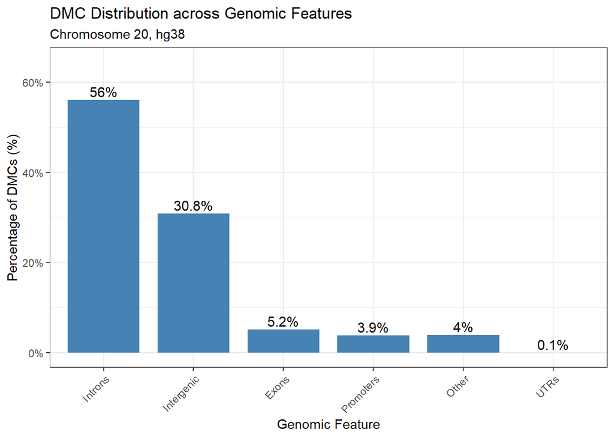

```r
# ------------------------------------------------------------
# 12. Plot grouped genomic features
# ------------------------------------------------------------

ggplot(
  feature_summary,
  aes(
    x = feature_group,
    y = percent
  )
) +
  geom_col(
    fill = "steelblue",
    width = 0.8
  ) +
  geom_text(
    aes(label = paste0(round(percent, 1), "%")),
    vjust = -0.3,
    size = 4
  ) +
  scale_y_continuous(
    limits = c(0, max(feature_summary$percent) * 1.15),
    labels = function(x) paste0(x, "%")
  ) +
  labs(
    title = "DMC Distribution across Genomic Features",
    subtitle = "Chromosome 20, hg38",
    x = "Genomic Feature",
    y = "Percentage of DMCs (%)"
  ) +
  theme_bw() +
  theme(
    axis.text.x = element_text(
      angle = 45,
      hjust = 1
    )
  )
```

```r
# ------------------------------------------------------------
# DMC enrichment in genomic features
# Correct version: background = all tested CpGs
# ------------------------------------------------------------

library(data.table)
library(GenomicRanges)
library(annotatr)
library(ggplot2)

# ------------------------------------------------------------
# 1. Start from ALL tested CpGs
# Do NOT filter this object before creating background
# ------------------------------------------------------------

dss_all_dt <- as.data.table(dmlTest)

dss_all_dt <- dss_all_dt[
  !is.na(chr) &
    !is.na(pos) &
    !is.na(fdr) &
    !is.na(diff)
]

# Make CpG ID
dss_all_dt[, cpg_id := paste0(chr, ":", pos)]

# Optional: if diff is control - tumour, reverse it
# If your diff is already tumour - control, remove this line
dss_all_dt[, tumour_diff := -diff]

# ------------------------------------------------------------
# 2. Define DMCs
# ------------------------------------------------------------

dmcs_dt <- dss_all_dt[
  fdr < 0.01 & abs(tumour_diff) >= 0.2
]

dmcs_dt[, dmc_index := .I]

dmcs_dt[, direction := fifelse(
  tumour_diff > 0,
  "Hypermethylated in tumour",
  "Hypomethylated in tumour"
)]

# Quick sanity check
cat("All tested CpGs:", nrow(dss_all_dt), "\n")
```

```
All tested CpGs: 551380
```

```r
cat("DMCs:", nrow(dmcs_dt), "\n")
```

```
DMCs: 14588
```

```r
# ------------------------------------------------------------
# 3. Create GRanges for DMCs
# ------------------------------------------------------------

dmcs_gr <- GRanges(
  seqnames = dmcs_dt$chr,
  ranges = IRanges(
    start = dmcs_dt$pos,
    width = 1
  ),
  cpg_id = dmcs_dt$cpg_id
)

# ------------------------------------------------------------
# 4. Annotate DMCs
# ------------------------------------------------------------

dmcs_annotated <- annotate_regions(
  regions = dmcs_gr,
  annotations = annotations,
  ignore.strand = TRUE,
  quiet = TRUE
)

dmcs_dt_annot <- as.data.table(dmcs_annotated)

dmcs_dt_annot[, annot_type := annot.type]
dmcs_dt_annot[, annot_type := gsub("hg38_", "", annot_type)]
dmcs_dt_annot[, annot_type := gsub("genes_", "", annot_type)]
dmcs_dt_annot[, annot_type := gsub("cpg_", "", annot_type)]

dmcs_dt_annot[, cpg_id := paste0(seqnames, ":", start)]

# ------------------------------------------------------------
# 5. Keep one annotation per DMC using priority
# ------------------------------------------------------------

dmcs_dt_annot[, annot_priority := fifelse(
  annot_type == "promoters", 1,
  fifelse(
    annot_type == "5UTRs", 2,
    fifelse(
      annot_type == "exons", 3,
      fifelse(
        annot_type == "introns", 4,
        fifelse(
          annot_type == "3UTRs", 5,
          fifelse(
            grepl("islands|shores|shelves|inter", annot_type), 6,
            7
          )
        )
      )
    )
  )
)]

setorder(dmcs_dt_annot, cpg_id, annot_priority)

dmc_features <- dmcs_dt_annot[, .SD[1], by = cpg_id]

# Add unannotated DMCs back if annotate_regions dropped them
dmc_features <- merge(
  dmcs_dt[, .(cpg_id, chr, pos)],
  dmc_features[, .(cpg_id, annot_type)],
  by = "cpg_id",
  all.x = TRUE
)

dmc_features[is.na(annot_type), annot_type := "unannotated"]

# ------------------------------------------------------------
# 6. Group DMC annotations
# ------------------------------------------------------------

dmc_features[, feature_group := fifelse(
  annot_type == "introns", "Introns",
  fifelse(
    annot_type == "intergenic", "Intergenic",
    fifelse(
      annot_type == "exons", "Exons",
      fifelse(
        annot_type == "promoters", "Promoters",
        fifelse(
          annot_type %in% c("5UTRs", "3UTRs"), "UTRs",
          "Other"
        )
      )
    )
  )
)]

dmc_features[, feature_group := factor(
  feature_group,
  levels = c(
    "Introns",
    "Intergenic",
    "Exons",
    "Promoters",
    "Other",
    "UTRs"
  )
)]

# ------------------------------------------------------------
# 7. DMC summary
# ------------------------------------------------------------

feature_summary <- dmc_features[
  ,
  .N,
  by = feature_group
]

feature_summary[, percent := 100 * N / sum(N)]

setorder(feature_summary, feature_group)

feature_summary
```

```
   feature_group     N     percent
          <fctr> <int>       <num>
1:       Introns  8170 56.00493556
2:    Intergenic  4500 30.84727173
3:         Exons   761  5.21661640
4:     Promoters   569  3.90046614
5:         Other   579  3.96901563
6:          UTRs     9  0.06169454
```

```r
# ------------------------------------------------------------
# 8. Create background from ALL tested CpGs
# ------------------------------------------------------------

background_dt <- copy(dss_all_dt)

background_gr <- GRanges(
  seqnames = background_dt$chr,
  ranges = IRanges(
    start = background_dt$pos,
    width = 1
  ),
  cpg_id = background_dt$cpg_id
)

# ------------------------------------------------------------
# 9. Annotate background CpGs
# ------------------------------------------------------------

background_annotated <- annotate_regions(
  regions = background_gr,
  annotations = annotations,
  ignore.strand = TRUE,
  quiet = TRUE
)

background_dt_annot <- as.data.table(background_annotated)

background_dt_annot[, annot_type := annot.type]
background_dt_annot[, annot_type := gsub("hg38_", "", annot_type)]
background_dt_annot[, annot_type := gsub("genes_", "", annot_type)]
background_dt_annot[, annot_type := gsub("cpg_", "", annot_type)]

background_dt_annot[, cpg_id := paste0(seqnames, ":", start)]

# ------------------------------------------------------------
# 10. Keep one annotation per background CpG using same priority
# ------------------------------------------------------------

background_dt_annot[, annot_priority := fifelse(
  annot_type == "promoters", 1,
  fifelse(
    annot_type == "5UTRs", 2,
    fifelse(
      annot_type == "exons", 3,
      fifelse(
        annot_type == "introns", 4,
        fifelse(
          annot_type == "3UTRs", 5,
          fifelse(
            grepl("islands|shores|shelves|inter", annot_type), 6,
            7
          )
        )
      )
    )
  )
)]

setorder(background_dt_annot, cpg_id, annot_priority)

background_features <- background_dt_annot[, .SD[1], by = cpg_id]

# Add unannotated background CpGs back
background_features <- merge(
  background_dt[, .(cpg_id, chr, pos)],
  background_features[, .(cpg_id, annot_type)],
  by = "cpg_id",
  all.x = TRUE
)

background_features[is.na(annot_type), annot_type := "unannotated"]

# ------------------------------------------------------------
# 11. Group background annotations
# ------------------------------------------------------------

background_features[, feature_group := fifelse(
  annot_type == "introns", "Introns",
  fifelse(
    annot_type == "intergenic", "Intergenic",
    fifelse(
      annot_type == "exons", "Exons",
      fifelse(
        annot_type == "promoters", "Promoters",
        fifelse(
          annot_type %in% c("5UTRs", "3UTRs"), "UTRs",
          "Other"
        )
      )
    )
  )
)]

background_features[, feature_group := factor(
  feature_group,
  levels = c(
    "Introns",
    "Intergenic",
    "Exons",
    "Promoters",
    "Other",
    "UTRs"
  )
)]

# ------------------------------------------------------------
# 12. Background summary
# ------------------------------------------------------------

background_summary <- background_features[
  ,
  .N,
  by = feature_group
]

setnames(background_summary, "N", "bg_N")

background_summary[, bg_percentage := 100 * bg_N / sum(bg_N)]

setorder(background_summary, feature_group)

background_summary
```

```
   feature_group   bg_N bg_percentage
          <fctr>  <int>         <num>
1:       Introns 310864    56.3792666
2:    Intergenic  16012     2.9039864
3:         Exons  44200     8.0162501
4:     Promoters  37717     6.8404730
5:         Other 141158    25.6008560
6:          UTRs   1429     0.2591679
```

```r
# ------------------------------------------------------------
# 13. Enrichment table
# Enrichment = DMC proportion / background proportion
# ------------------------------------------------------------

enrichment_table <- merge(
  feature_summary,
  background_summary,
  by = "feature_group",
  all = TRUE
)

setnames(enrichment_table, "N", "dmc_N")
setnames(enrichment_table, "percent", "dmc_percentage")

enrichment_table[is.na(dmc_N), dmc_N := 0]
enrichment_table[is.na(dmc_percentage), dmc_percentage := 0]
enrichment_table[is.na(bg_N), bg_N := 0]
enrichment_table[is.na(bg_percentage), bg_percentage := 0]

enrichment_table[, enrichment := dmc_percentage / bg_percentage]

# Avoid Inf or NaN if background percentage is zero
enrichment_table[bg_percentage == 0, enrichment := NA_real_]

enrichment_table[, log2_enrichment := log2(enrichment)]

enrichment_table[, enrichment_status := fifelse(
  enrichment > 1,
  "Enriched",
  "Depleted"
)]

setorder(enrichment_table, feature_group)

enrichment_table
```

```
Key: <feature_group>
Index: <bg_percentage>
   feature_group dmc_N dmc_percentage   bg_N bg_percentage enrichment
          <fctr> <int>          <num>  <int>         <num>      <num>
1:       Introns  8170    56.00493556 310864    56.3792666  0.9933605
2:    Intergenic  4500    30.84727173  16012     2.9039864 10.6223886
3:         Exons   761     5.21661640  44200     8.0162501  0.6507552
4:     Promoters   569     3.90046614  37717     6.8404730  0.5702042
5:         Other   579     3.96901563 141158    25.6008560  0.1550345
6:          UTRs     9     0.06169454   1429     0.2591679  0.2380485
   log2_enrichment enrichment_status
             <num>            <char>
1:    -0.009610737          Depleted
2:     3.409036314          Enriched
3:    -0.619813178          Depleted
4:    -0.810449538          Depleted
5:    -2.689338903          Depleted
6:    -2.070672272          Depleted
```

```r
# ------------------------------------------------------------
# 14. Sanity checks
# ------------------------------------------------------------

cat("Unique tested CpGs:", length(unique(dss_all_dt$cpg_id)), "\n")
```

```
Unique tested CpGs: 551380
```

```r
cat("Unique DMC CpGs:", length(unique(dmcs_dt$cpg_id)), "\n")
```

```
Unique DMC CpGs: 14588
```

```r
cat("Annotated background CpGs:", nrow(background_features), "\n")
```

```
Annotated background CpGs: 551380
```

```r
cat("Annotated DMC CpGs:", nrow(dmc_features), "\n")
```

```
Annotated DMC CpGs: 14588
```

```r
print(enrichment_table)
```

```
Key: <feature_group>
Index: <bg_percentage>
   feature_group dmc_N dmc_percentage   bg_N bg_percentage enrichment
          <fctr> <int>          <num>  <int>         <num>      <num>
1:       Introns  8170    56.00493556 310864    56.3792666  0.9933605
2:    Intergenic  4500    30.84727173  16012     2.9039864 10.6223886
3:         Exons   761     5.21661640  44200     8.0162501  0.6507552
4:     Promoters   569     3.90046614  37717     6.8404730  0.5702042
5:         Other   579     3.96901563 141158    25.6008560  0.1550345
6:          UTRs     9     0.06169454   1429     0.2591679  0.2380485
   log2_enrichment enrichment_status
             <num>            <char>
1:    -0.009610737          Depleted
2:     3.409036314          Enriched
3:    -0.619813178          Depleted
4:    -0.810449538          Depleted
5:    -2.689338903          Depleted
6:    -2.070672272          Depleted
```

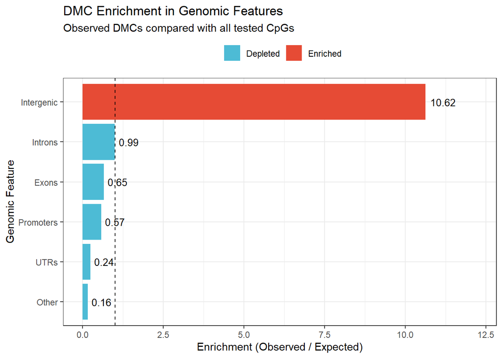

```r
# ------------------------------------------------------------
# 15. Enrichment plot
# ------------------------------------------------------------

ggplot(
  enrichment_table[!is.na(enrichment)],
  aes(
    x = reorder(feature_group, enrichment),
    y = enrichment,
    fill = enrichment_status
  )
) +
  geom_col() +
  geom_hline(
    yintercept = 1,
    linetype = "dashed",
    color = "black"
  ) +
  geom_text(
    aes(label = round(enrichment, 2)),
    hjust = -0.2,
    size = 3.5
  ) +
  coord_flip() +
  scale_fill_manual(
    values = c(
      "Enriched" = "#E64B35",
      "Depleted" = "#4DBBD5"
    )
  ) +
  scale_y_continuous(
    limits = c(
      0,
      max(enrichment_table$enrichment, na.rm = TRUE) * 1.15
    )
  ) +
  labs(
    title = "DMC Enrichment in Genomic Features",
    subtitle = "Observed DMCs compared with all tested CpGs",
    x = "Genomic Feature",
    y = "Enrichment (Observed / Expected)",
    fill = ""
  ) +
  theme_bw() +
  theme(
    legend.position = "top"
  )
```

```r
# ------------------------------------------------------------
# Hyper vs hypo DMC distribution across genomic features
# ------------------------------------------------------------

feature_by_direction <- dmcs_final[
  ,
  .N,
  by = .(feature_group, direction)
]

feature_by_direction[, total := sum(N), by = direction]
feature_by_direction[, percentage := 100 * N / total]

feature_by_direction
```

```
    feature_group                 direction     N total  percentage
           <fctr>                    <char> <int> <int>       <num>
 1:    Intergenic Hypermethylated in tumour  4487 14391 31.17920923
 2:         Other Hypermethylated in tumour   569 14391  3.95386005
 3:       Introns Hypermethylated in tumour  8066 14391 56.04891946
 4:         Exons Hypermethylated in tumour   717 14391  4.98228059
 5:     Promoters Hypermethylated in tumour   543 14391  3.77319158
 6:         Other  Hypomethylated in tumour    10   197  5.07614213
 7:          UTRs Hypermethylated in tumour     9 14391  0.06253909
 8:         Exons  Hypomethylated in tumour    44   197 22.33502538
 9:       Introns  Hypomethylated in tumour   104   197 52.79187817
10:     Promoters  Hypomethylated in tumour    26   197 13.19796954
11:    Intergenic  Hypomethylated in tumour    13   197  6.59898477
```

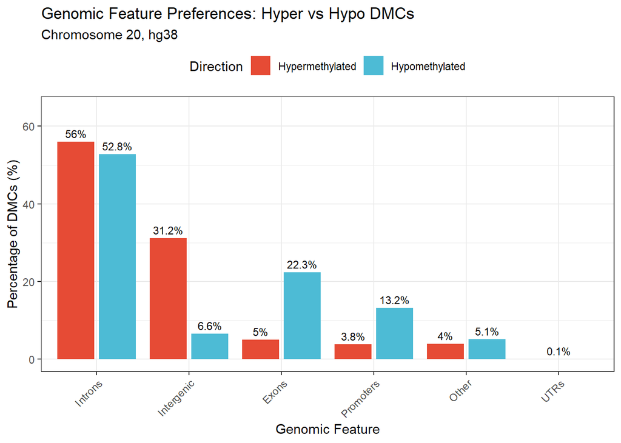

```r
ggplot(
  feature_by_direction,
  aes(
    x = feature_group,
    y = percentage,
    fill = direction
  )
) +
  geom_col(
    position = position_dodge(width = 0.9),
    width = 0.8
  ) +
  geom_text(
    aes(label = paste0(round(percentage, 1), "%")),
    position = position_dodge(width = 0.9),
    vjust = -0.5,
    size = 3
  ) +
  scale_fill_manual(
    values = c(
      "Hypermethylated in tumour" = "#E64B35",
      "Hypomethylated in tumour" = "#4DBBD5"
    ),
    labels = c(
      "Hypermethylated in tumour" = "Hypermethylated",
      "Hypomethylated in tumour" = "Hypomethylated"
    )
  ) +
  scale_y_continuous(
    limits = c(0, max(feature_by_direction$percentage, na.rm = TRUE) * 1.15)
  ) +
  labs(
    title = "Genomic Feature Preferences: Hyper vs Hypo DMCs",
    subtitle = "Chromosome 20, hg38",
    x = "Genomic Feature",
    y = "Percentage of DMCs (%)",
    fill = "Direction"
  ) +
  theme_bw() +
  theme(
    axis.text.x = element_text(
      angle = 45,
      hjust = 1
    ),
    legend.position = "top"
  )
```

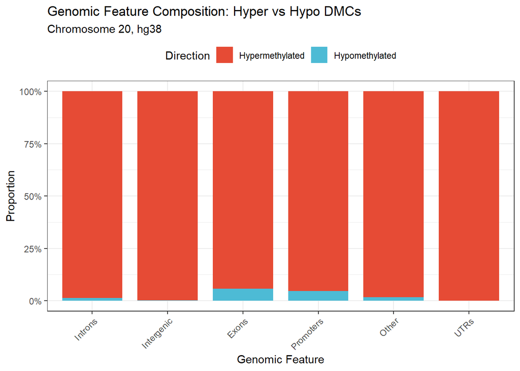

```r
# ------------------------------------------------------------
# Hyper vs hypo composition within each genomic feature
# ------------------------------------------------------------

ggplot(
  feature_by_direction,
  aes(
    x = feature_group,
    y = N,
    fill = direction
  )
) +
  geom_col(
    position = "fill",
    width = 0.8
  ) +
  scale_fill_manual(
    values = c(
      "Hypermethylated in tumour" = "#E64B35",
      "Hypomethylated in tumour" = "#4DBBD5"
    ),
    labels = c(
      "Hypermethylated in tumour" = "Hypermethylated",
      "Hypomethylated in tumour" = "Hypomethylated"
    )
  ) +
  scale_y_continuous(
    labels = scales::percent
  ) +
  labs(
    title = "Genomic Feature Composition: Hyper vs Hypo DMCs",
    subtitle = "Chromosome 20, hg38",
    x = "Genomic Feature",
    y = "Proportion",
    fill = "Direction"
  ) +
  theme_bw() +
  theme(
    axis.text.x = element_text(
      angle = 45,
      hjust = 1
    ),
    legend.position = "top"
  )
```

# DMR calling

Identify differentially methylated regions (DMRs). Test at least 3 parameter sets (see below). Compare results (number of DMRs, length, and CpG density), choose optimal parameters set (you can use your own set if you see that it is better); and justify your decision.

- minCG=3, minlen=50, p=0.05
- minCG=5, minlen=100, p=0.01
- minCG=7, minlen=200, p=0.01

```r
# ------------------------------------------------------------
# DMR calling with different parameter sets
# ------------------------------------------------------------

# Parameter sets required in the task
dmr_params <- data.frame(
  Parameter_set = c(
    "Set 1: minCG=3, minlen=50, p=0.05",
    "Set 2: minCG=5, minlen=100, p=0.01",
    "Set 3: minCG=7, minlen=200, p=0.01"
  ),
  minCG = c(3, 5, 7),
  minlen = c(50, 100, 200),
  p_threshold = c(0.05, 0.01, 0.01)
)

## Function to call DMRs and summarize them
run_dmr_calling <- function(minCG, minlen, p_threshold, set_name) {

  dmrs <- callDMR(
    dmlTest,
    p.threshold = p_threshold,
    minCG = minCG,
    minlen = minlen
  )

  dmrs_dt <- as.data.table(dmrs)

  if (nrow(dmrs_dt) == 0) {
    summary_dt <- data.table(
      Parameter_set = set_name,
      minCG = minCG,
      minlen = minlen,
      p_threshold = p_threshold,
      Number_of_DMRs = 0,
      Mean_length_bp = NA_real_,
      Median_length_bp = NA_real_,
      Mean_CpGs_per_DMR = NA_real_,
      Mean_CpG_density_per_kb = NA_real_,
      Mean_abs_methylation_difference = NA_real_
    )
  } else {

    # Check column names
    print(names(dmrs_dt))

    # DMR length
    dmrs_dt[, length_bp := end - start + 1]

    # CpG density
    dmrs_dt[, CpG_density_per_kb := nCG / length_bp * 1000]

    # DSS usually uses diff.Methy, not meanDiff
    if ("diff.Methy" %in% names(dmrs_dt)) {
      meth_diff <- as.numeric(dmrs_dt$diff.Methy)
    } else if ("meanDiff" %in% names(dmrs_dt)) {
      meth_diff <- as.numeric(dmrs_dt$meanDiff)
    } else {
      meth_diff <- rep(NA_real_, nrow(dmrs_dt))
    }

    summary_dt <- data.table(
      Parameter_set = set_name,
      minCG = minCG,
      minlen = minlen,
      p_threshold = p_threshold,
      Number_of_DMRs = nrow(dmrs_dt),
      Mean_length_bp = mean(dmrs_dt$length_bp, na.rm = TRUE),
      Median_length_bp = median(dmrs_dt$length_bp, na.rm = TRUE),
      Mean_CpGs_per_DMR = mean(as.numeric(dmrs_dt$nCG), na.rm = TRUE),
      Mean_CpG_density_per_kb = mean(dmrs_dt$CpG_density_per_kb, na.rm = TRUE),
      Mean_abs_methylation_difference = mean(abs(meth_diff), na.rm = TRUE)
    )
  }

  list(
    dmrs = dmrs_dt,
    summary = summary_dt
  )
}

# Run all 3 parameter sets
dmr_results <- lapply(seq_len(nrow(dmr_params)), function(i) {
  run_dmr_calling(
    minCG = dmr_params$minCG[i],
    minlen = dmr_params$minlen[i],
    p_threshold = dmr_params$p_threshold[i],
    set_name = dmr_params$Parameter_set[i]
  )
})
```

```
[1] "chr"        "start"      "end"        "length"     "nCG"
[6] "meanMethy1" "meanMethy2" "diff.Methy" "areaStat"
[1] "chr"        "start"      "end"        "length"     "nCG"
[6] "meanMethy1" "meanMethy2" "diff.Methy" "areaStat"
[1] "chr"        "start"      "end"        "length"     "nCG"
[6] "meanMethy1" "meanMethy2" "diff.Methy" "areaStat"
```

```r
names(dmr_results) <- dmr_params$Parameter_set

# Combine summaries
dmr_summary <- rbindlist(
  lapply(dmr_results, function(x) x$summary),
  fill = TRUE
)

dmr_summary
```

```
                        Parameter_set minCG minlen p_threshold Number_of_DMRs
                               <char> <num>  <num>       <num>          <int>
1:  Set 1: minCG=3, minlen=50, p=0.05     3     50        0.05           5909
2: Set 2: minCG=5, minlen=100, p=0.01     5    100        0.01           1063
3: Set 3: minCG=7, minlen=200, p=0.01     7    200        0.01            380
   Mean_length_bp Median_length_bp Mean_CpGs_per_DMR Mean_CpG_density_per_kb
            <num>            <num>             <num>                   <num>
1:       398.6869              248          6.380606                33.87943
2:       372.1938              254          8.735654                35.82586
3:       506.0684              402         11.355263                29.39865
   Mean_abs_methylation_difference
                             <num>
1:                       0.4297884
2:                       0.4640238
3:                       0.4658033
```

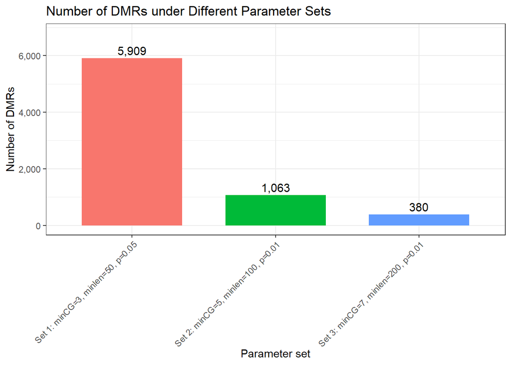

```r
ggplot(dmr_summary, aes(x = Parameter_set, y = Number_of_DMRs, fill = Parameter_set)) +
  geom_col(show.legend = FALSE, width = 0.7) +
  geom_text(aes(label = scales::comma(Number_of_DMRs)), vjust = -0.4, size = 4) +
  scale_y_continuous(
    labels = scales::comma,
    limits = c(0, max(dmr_summary$Number_of_DMRs, na.rm = TRUE) * 1.15)
  ) +
  labs(
    title = "Number of DMRs under Different Parameter Sets",
    x = "Parameter set",
    y = "Number of DMRs"
  ) +
  theme_bw() +
  theme(axis.text.x = element_text(angle = 45, hjust = 1))
```

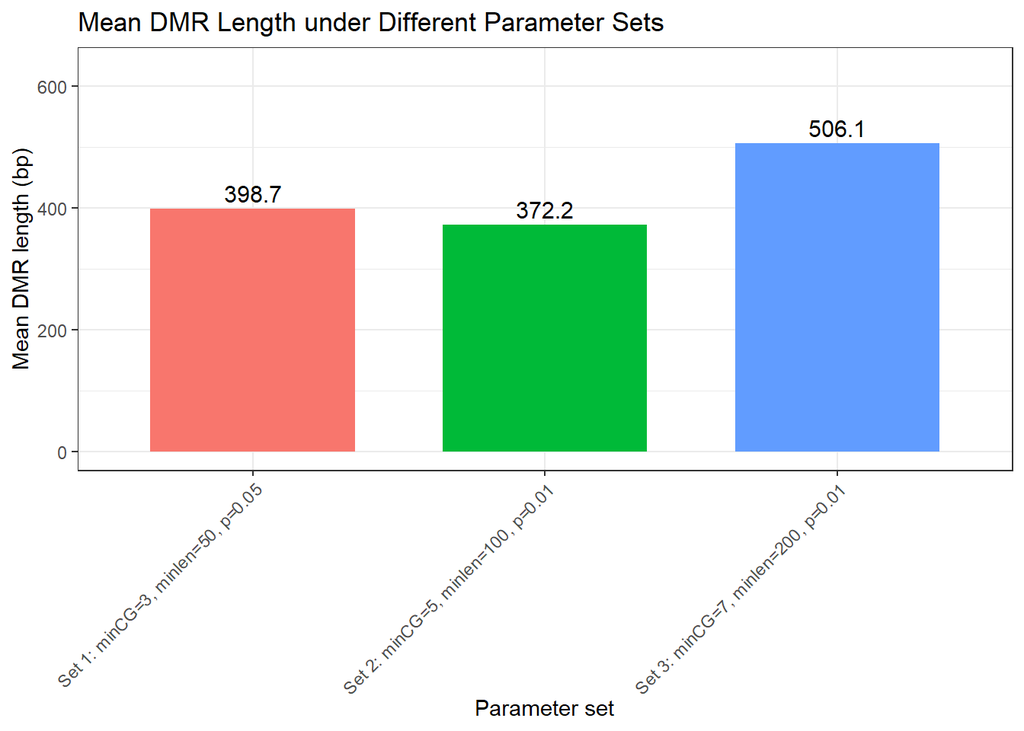

```r
ggplot(dmr_summary, aes(x = Parameter_set, y = Mean_length_bp, fill = Parameter_set)) +
  geom_col(show.legend = FALSE, width = 0.7) +
  geom_text(aes(label = round(Mean_length_bp, 1)), vjust = -0.4, size = 4) +
  scale_y_continuous(
    limits = c(0, max(dmr_summary$Mean_length_bp, na.rm = TRUE) * 1.25)
  ) +
  labs(
    title = "Mean DMR Length under Different Parameter Sets",
    x = "Parameter set",
    y = "Mean DMR length (bp)"
  ) +
  theme_bw() +
  theme(axis.text.x = element_text(angle = 45, hjust = 1))
```

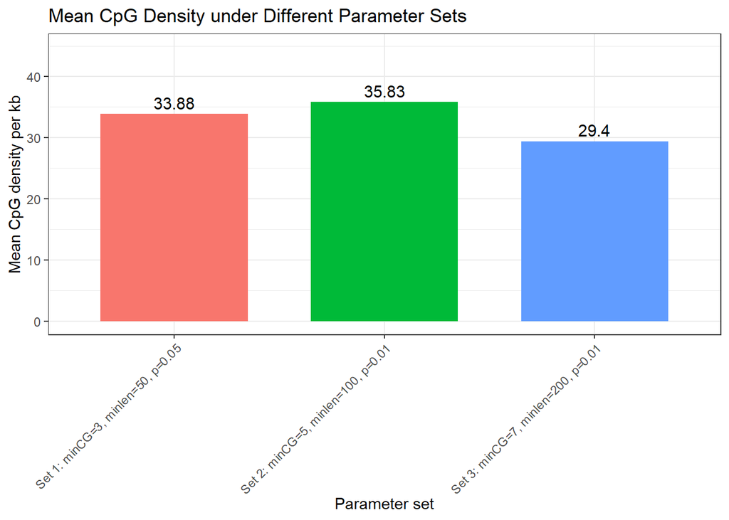

```r
ggplot(dmr_summary, aes(x = Parameter_set, y = Mean_CpG_density_per_kb, fill = Parameter_set)) +
  geom_col(show.legend = FALSE, width = 0.7) +
  geom_text(aes(label = round(Mean_CpG_density_per_kb, 2)), vjust = -0.4, size = 4) +
  scale_y_continuous(
    limits = c(0, max(dmr_summary$Mean_CpG_density_per_kb, na.rm = TRUE) * 1.25)
  ) +
  labs(
    title = "Mean CpG Density under Different Parameter Sets",
    x = "Parameter set",
    y = "Mean CpG density per kb"
  ) +
  theme_bw() +
  theme(axis.text.x = element_text(angle = 45, hjust = 1))
```

Characterize your DMRs. Show Length distribution, CpGs per DMR distribution, chromosome distribution, hyper vs hypo properties, density plot across genome, correlation between DMR length and effect size.

```r
# ------------------------------------------------------------
# Characterize selected DMRs: Set 2
# minCG = 5, minlen = 100, p = 0.01
# ------------------------------------------------------------

# Select Set 2 DMRs
optimal_dmrs <- as.data.table(dmr_results[[2]]$dmrs)

optimal_dmrs <- optimal_dmrs %>%
  mutate(
    length_bp = end - start + 1,
    CpG_density_per_kb = nCG / length_bp * 1000,

    # DSS diff.Methy follows group1 - group2
    # group1 = healthy, group2 = tumour
    # so positive diff.Methy = higher methylation in healthy
    # tumour_diff flips it so positive = higher methylation in tumour
    tumour_diff = -diff.Methy,

    effect_size = tumour_diff,
    abs_effect_size = abs(tumour_diff),

    methylation_direction = ifelse(
      tumour_diff > 0,
      "Hypermethylated in tumour",
      "Hypomethylated in tumour"
    ),

    midpoint = (start + end) / 2
  )
# Summary table
dmr_characterization_summary <- optimal_dmrs %>%
  summarise(
    Number_of_DMRs = n(),
    Mean_length_bp = mean(length_bp, na.rm = TRUE),
    Median_length_bp = median(length_bp, na.rm = TRUE),
    Mean_CpGs_per_DMR = mean(nCG, na.rm = TRUE),
    Median_CpGs_per_DMR = median(nCG, na.rm = TRUE),
    Mean_CpG_density_per_kb = mean(CpG_density_per_kb, na.rm = TRUE),
    Mean_abs_effect_size = mean(abs_effect_size, na.rm = TRUE),
    Hypermethylated_DMRs = sum(methylation_direction == "Hypermethylated in tumour"),
    Hypomethylated_DMRs = sum(methylation_direction == "Hypomethylated in tumour")
  )

dmr_characterization_summary
```

```
  Number_of_DMRs Mean_length_bp Median_length_bp Mean_CpGs_per_DMR
1           1063       372.1938              254          8.735654
  Median_CpGs_per_DMR Mean_CpG_density_per_kb Mean_abs_effect_size
1                   8                35.82586            0.4640238
  Hypermethylated_DMRs Hypomethylated_DMRs
1                 1051                  12
```

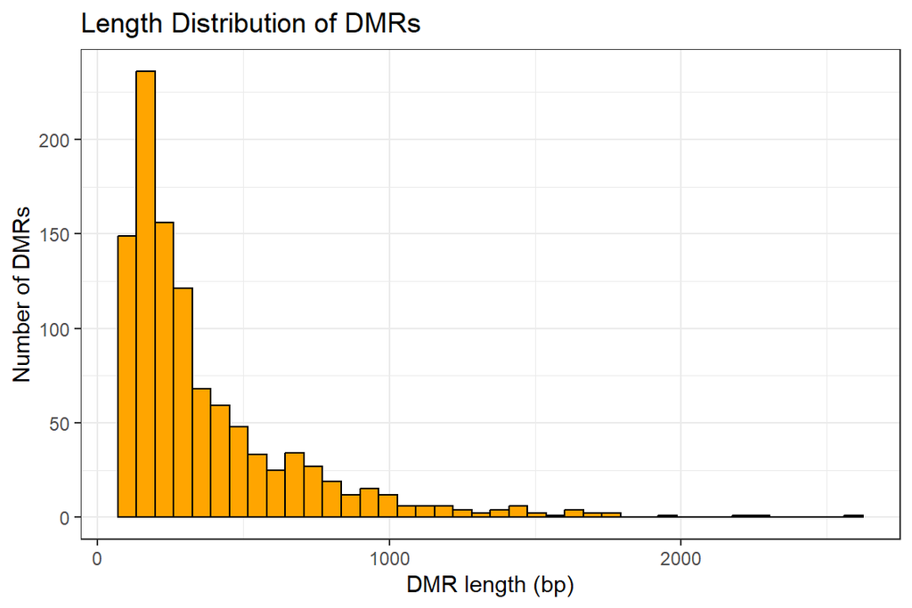

```r
ggplot(optimal_dmrs, aes(x = length_bp)) +
  geom_histogram(bins = 40, color = "black", fill = "orange") +
  labs(
    title = "Length Distribution of DMRs",
    x = "DMR length (bp)",
    y = "Number of DMRs"
  ) +
  theme_bw()
```

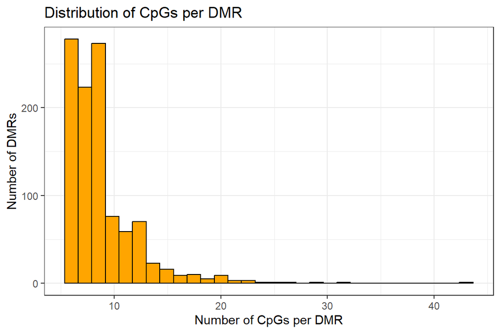

```r
ggplot(optimal_dmrs, aes(x = nCG)) +
  geom_histogram(bins = 30, color = "black", fill = "orange") +
  labs(
    title = "Distribution of CpGs per DMR",
    x = "Number of CpGs per DMR",
    y = "Number of DMRs"
  ) +
  theme_bw()
```

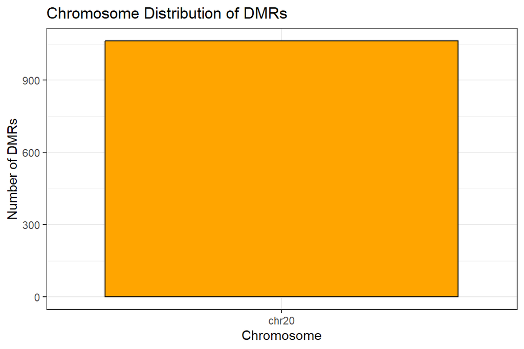

```r
ggplot(optimal_dmrs, aes(x = chr)) +
  geom_bar(fill = "orange", color = "black") +
  labs(
    title = "Chromosome Distribution of DMRs",
    x = "Chromosome",
    y = "Number of DMRs"
  ) +
  theme_bw()
```

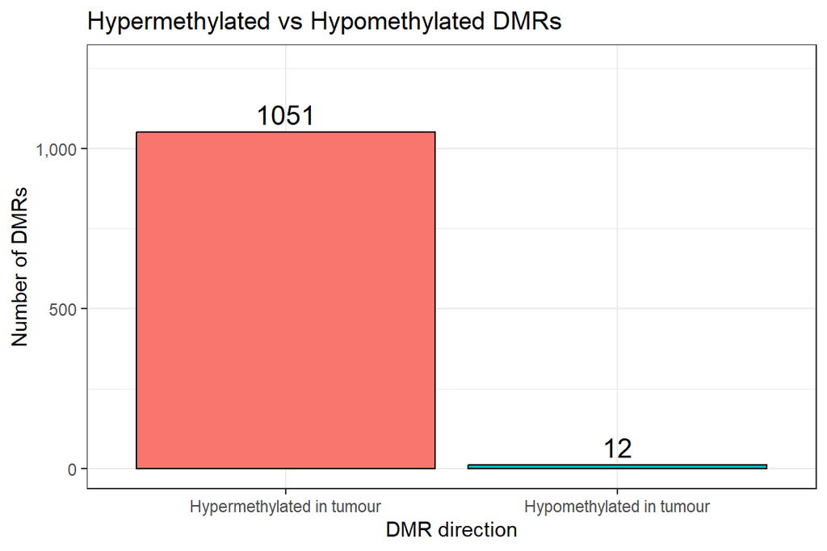

```r
ggplot(optimal_dmrs, aes(x = methylation_direction, fill = methylation_direction)) +
  geom_bar(color = "black", show.legend = FALSE) +
  geom_text(
    stat = "count",
    aes(label = after_stat(count)),
    vjust = -0.4,
    size = 5
  ) +
  scale_y_continuous(
    labels = scales::comma,
    limits = c(0, max(table(optimal_dmrs$methylation_direction)) * 1.2)
  ) +
  labs(
    title = "Hypermethylated vs Hypomethylated DMRs",
    x = "DMR direction",
    y = "Number of DMRs"
  ) +
  theme_bw()
```

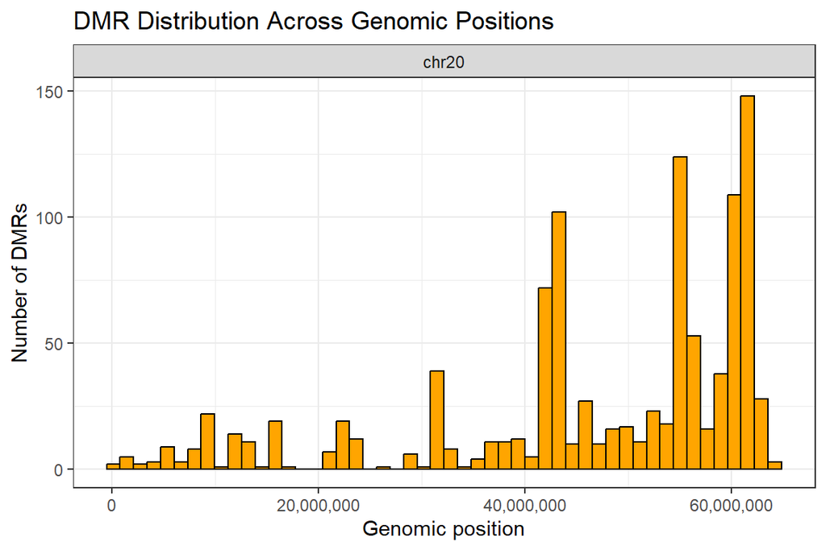

```r
ggplot(optimal_dmrs, aes(x = midpoint)) +
  geom_histogram(bins = 50, fill = "orange", color = "black") +
  facet_wrap(~ chr, scales = "free_x") +
  scale_x_continuous(labels = comma) +
  labs(
    title = "DMR Distribution Across Genomic Positions",
    x = "Genomic position",
    y = "Number of DMRs"
  ) +
  theme_bw()
```

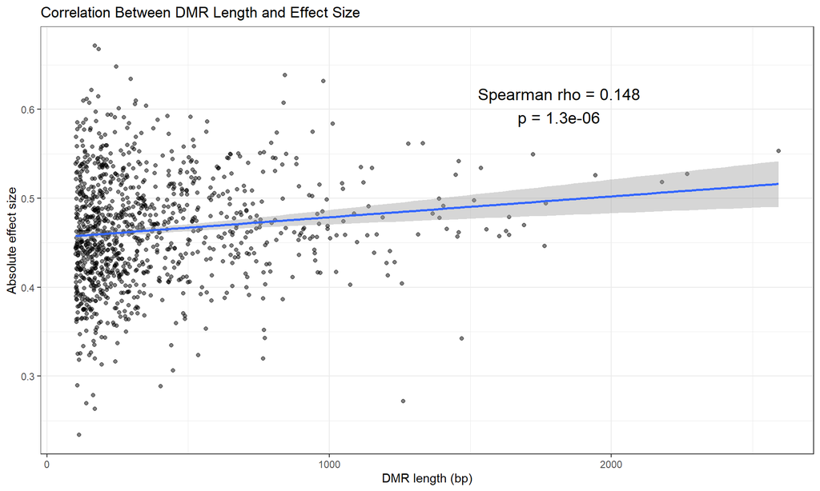

```r
cor_test <- cor.test(
  optimal_dmrs$length_bp,
  optimal_dmrs$abs_effect_size,
  method = "spearman"
)
cor_label <- paste0(
  "Spearman rho = ", round(cor_test$estimate, 3),
  "\np = ", signif(cor_test$p.value, 3)
)

ggplot(optimal_dmrs, aes(x = length_bp, y = abs_effect_size)) +
  geom_point(alpha = 0.5) +
  geom_smooth(method = "lm", se = TRUE) +
  annotate(
    "text",
    x = max(optimal_dmrs$length_bp, na.rm = TRUE) * 0.7,
    y = max(optimal_dmrs$abs_effect_size, na.rm = TRUE) * 0.9,
    label = cor_label,
    size = 5
  ) +
  labs(
    title = "Correlation Between DMR Length and Effect Size",
    x = "DMR length (bp)",
    y = "Absolute effect size"
  ) +
  theme_bw()
```

Save a list of DMRs including:

- genomic coordinates,
- number of CpGs per region,
- mean methylation difference,
- statistical significance.

```r
# ------------------------------------------------------------
# Save final DMR list from optimal parameter set
# ------------------------------------------------------------

final_dmrs <- optimal_dmrs %>%
  dplyr::mutate(
    genomic_coordinates = paste0(chr, ":", start, "-", end)
  ) %>%
  dplyr::select(
    chr,
    start,
    end,
    genomic_coordinates,
    nCG,
    diff.Methy,
    tumour_diff,
    methylation_direction,
    areaStat
  ) %>%
  dplyr::rename(
    chromosome = chr,
    region_start = start,
    region_end = end,
    number_of_CpGs = nCG,
    healthy_minus_tumour_difference = diff.Methy,
    tumour_minus_healthy_difference = tumour_diff,
    statistical_significance = areaStat
  )

write.csv(final_dmrs, "final_dmrs_list.csv", row.names = FALSE)
```

Compare DMCs and DMR. Calculate and plot the number/fractions of DMCs falling within DMRs; number of isolated DMRs. Calculate enrichment in promoters, CGI).

```r
# ------------------------------------------------------------
# 4. Compare DMCs and DMRs
# ------------------------------------------------------------

# ------------------------------------------------------------
# Create significant DMC list
# ------------------------------------------------------------
# DSS callDML extracts significant differentially methylated CpG sites.
# You can change p.threshold if needed, but 0.01 matches the selected DMR p-value.

# ------------------------------------------------------------
# Create final significant DMC list
# chosen threshold: FDR < 0.01 and |Δβ| >= 0.20
# ------------------------------------------------------------

dmcs_all <- as.data.table(dmlTest)

dmcs_sig <- dmcs_all %>%
  dplyr::filter(
    fdr < 0.01,
    abs(diff) >= 0.20
  )


# ------------------------------------------------------------
# Convert DMCs and DMRs to GRanges
# ------------------------------------------------------------
library(GenomicRanges)
library(IRanges)

dmcs_gr <- GRanges(
  seqnames = dmcs_sig$chr,
  ranges = IRanges(
    start = dmcs_sig$pos,
    end = dmcs_sig$pos
  )
)

# Keep only columns that definitely exist (senas var)
# dmcs_gr <- GRanges(
#   seqnames = dmcs$chr,
#   ranges = IRanges(
#     start = dmcs$pos,
#     end = dmcs$pos
#   )
# )

# Add metadata only if the columns exist
if ("diff" %in% names(dmcs_sig)) {
  mcols(dmcs_gr)$diff <- dmcs_sig$diff
}

if ("pvals" %in% names(dmcs_sig)) {
  mcols(dmcs_gr)$pval <- dmcs_sig$pvals
}

if ("pval" %in% names(dmcs_sig)) {
  mcols(dmcs_gr)$pval <- dmcs_sig$pval
}

if ("qvals" %in% names(dmcs_sig)) {
  mcols(dmcs_gr)$qval <- dmcs_sig$qvals
}

if ("qval" %in% names(dmcs_sig)) {
  mcols(dmcs_gr)$qval <- dmcs_sig$qval
}

dmrs_gr <- GRanges(
  seqnames = optimal_dmrs$chr,
  ranges = IRanges(
    start = optimal_dmrs$start,
    end = optimal_dmrs$end
  ),
  nCG = optimal_dmrs$nCG,
  diff.Methy = optimal_dmrs$diff.Methy,
  areaStat = optimal_dmrs$areaStat
)

# ------------------------------------------------------------
# DMCs falling within DMRs
# ------------------------------------------------------------

dmc_in_dmr_hits <- findOverlaps(dmcs_gr, dmrs_gr)

number_dmcs_total <- length(dmcs_gr)
number_dmcs_in_dmrs <- length(unique(queryHits(dmc_in_dmr_hits)))
number_dmcs_outside_dmrs <- number_dmcs_total - number_dmcs_in_dmrs

fraction_dmcs_in_dmrs <- number_dmcs_in_dmrs / number_dmcs_total
fraction_dmcs_outside_dmrs <- number_dmcs_outside_dmrs / number_dmcs_total

# ------------------------------------------------------------
# DMRs containing at least one DMC and isolated DMRs
# ------------------------------------------------------------

number_dmrs_total <- length(dmrs_gr)
number_dmrs_with_dmcs <- length(unique(subjectHits(dmc_in_dmr_hits)))
number_isolated_dmrs <- number_dmrs_total - number_dmrs_with_dmcs

fraction_dmrs_with_dmcs <- number_dmrs_with_dmcs / number_dmrs_total
fraction_isolated_dmrs <- number_isolated_dmrs / number_dmrs_total

comparison_summary <- data.frame(
  Category = c(
    "Total DMCs",
    "DMCs inside DMRs",
    "DMCs outside DMRs",
    "Total DMRs",
    "DMRs with at least one DMC",
    "Isolated DMRs"
  ),
  Number = c(
    number_dmcs_total,
    number_dmcs_in_dmrs,
    number_dmcs_outside_dmrs,
    number_dmrs_total,
    number_dmrs_with_dmcs,
    number_isolated_dmrs
  ),
  Fraction = c(
    NA,
    fraction_dmcs_in_dmrs,
    fraction_dmcs_outside_dmrs,
    NA,
    fraction_dmrs_with_dmcs,
    fraction_isolated_dmrs
  )
)

comparison_summary
```

```
                    Category Number  Fraction
1                 Total DMCs  14588        NA
2           DMCs inside DMRs   2751 0.1885797
3          DMCs outside DMRs  11837 0.8114203
4                 Total DMRs   1063        NA
5 DMRs with at least one DMC    935 0.8795861
6              Isolated DMRs    128 0.1204139
```

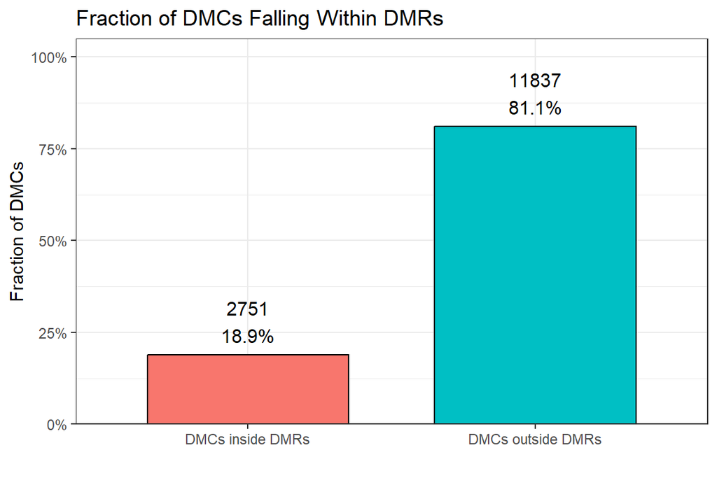

```r
dmc_fraction_plot <- data.frame(
  Category = c("DMCs inside DMRs", "DMCs outside DMRs"),
  Number = c(number_dmcs_in_dmrs, number_dmcs_outside_dmrs),
  Fraction = c(fraction_dmcs_in_dmrs, fraction_dmcs_outside_dmrs)
)

ggplot(dmc_fraction_plot, aes(x = Category, y = Fraction, fill = Category)) +
  geom_col(show.legend = FALSE, color = "black", width = 0.7) +
  geom_text(
    aes(label = paste0(Number, "\n", percent(Fraction, accuracy = 0.1))),
    vjust = -0.3,
    size = 4
  ) +
  scale_y_continuous(
  labels = percent_format(accuracy = 1),
  limits = c(0, 1),
  expand = expansion(mult = c(0, 0.05))
) +
  labs(
    title = "Fraction of DMCs Falling Within DMRs",
    x = "",
    y = "Fraction of DMCs"
  ) +
  theme_bw()
```

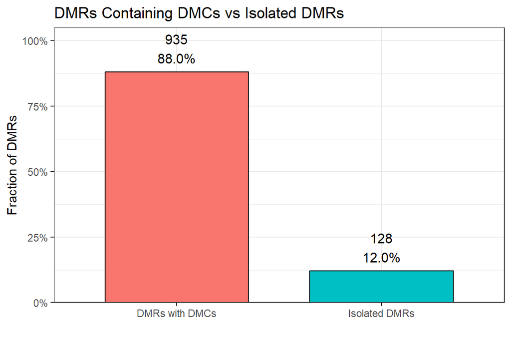

```r
dmr_isolation_plot <- data.frame(
  Category = c("DMRs with DMCs", "Isolated DMRs"),
  Number = c(number_dmrs_with_dmcs, number_isolated_dmrs),
  Fraction = c(fraction_dmrs_with_dmcs, fraction_isolated_dmrs)
)

ggplot(dmr_isolation_plot, aes(x = Category, y = Fraction, fill = Category)) +
  geom_col(show.legend = FALSE, color = "black", width = 0.7) +
  geom_text(
    aes(label = paste0(Number, "\n", percent(Fraction, accuracy = 0.1))),
    vjust = -0.3,
    size = 4
  ) +
  scale_y_continuous(
  labels = percent_format(accuracy = 1),
  limits = c(0, 1),
  expand = expansion(mult = c(0, 0.05))
  ) +
  labs(
    title = "DMRs Containing DMCs vs Isolated DMRs",
    x = "",
    y = "Fraction of DMRs"
  ) +
  theme_bw()
```

```r
# ------------------------------------------------------------
# Promoter and CpG island enrichment
# ------------------------------------------------------------

library(annotatr)

# Change to hg19 if your data are aligned to hg19
genome_build <- "hg38"

annotations <- build_annotations(
  genome = genome_build,
  annotations = c(
    paste0(genome_build, "_basicgenes"),
    paste0(genome_build, "_cpgs")
  )
)
```

```
Building promoters...
```

```
Building 1to5kb upstream of TSS...
```

```
Building 5UTRs...
```

```
Building 3UTRs...
```

```
Building exons...
```

```
Building introns...
```

```
Building CpG islands...
```

```
Building CpG shores...
```

```
Building CpG shelves...
```

```
Building inter-CpG-islands...
```

```r
dmr_annotations <- annotate_regions(
  regions = dmrs_gr,
  annotations = annotations,
  ignore.strand = TRUE,
  quiet = TRUE
)

dmr_annotations_df <- as.data.frame(dmr_annotations)

# Check annotation names
table(dmr_annotations_df$annot.type)
```

```
      hg38_cpg_inter     hg38_cpg_islands     hg38_cpg_shelves
                 995                   13                   35
     hg38_cpg_shores    hg38_genes_1to5kb     hg38_genes_3UTRs
                  32                  374                   42
    hg38_genes_5UTRs     hg38_genes_exons   hg38_genes_introns
                   2                  283                 4533
hg38_genes_promoters
                  98
```

```r
# ------------------------------------------------------------
# Count DMRs overlapping promoters and CpG islands
# ------------------------------------------------------------

dmr_annotation_summary <- dmr_annotations_df %>%
  dplyr::mutate(
    DMR_id = paste(seqnames, start, end, sep = "_"),
    in_promoter = grepl("promoter", annot.type, ignore.case = TRUE),
    in_CGI = grepl("cpg_islands", annot.type, ignore.case = TRUE)
  ) %>%
  dplyr::group_by(DMR_id) %>%
  dplyr::summarise(
    promoter_overlap = any(in_promoter),
    CGI_overlap = any(in_CGI),
    .groups = "drop"
  )

number_dmrs_in_promoters <- sum(dmr_annotation_summary$promoter_overlap)
number_dmrs_in_CGI <- sum(dmr_annotation_summary$CGI_overlap)

fraction_dmrs_in_promoters <- number_dmrs_in_promoters / number_dmrs_total
fraction_dmrs_in_CGI <- number_dmrs_in_CGI / number_dmrs_total

annotation_enrichment_summary <- data.frame(
  Annotation = c("Promoters", "CpG islands"),
  Number_of_DMRs = c(number_dmrs_in_promoters, number_dmrs_in_CGI),
  Fraction_of_DMRs = c(fraction_dmrs_in_promoters, fraction_dmrs_in_CGI)
)

annotation_enrichment_summary
```

```
   Annotation Number_of_DMRs Fraction_of_DMRs
1   Promoters             43       0.04045155
2 CpG islands             13       0.01222954
```

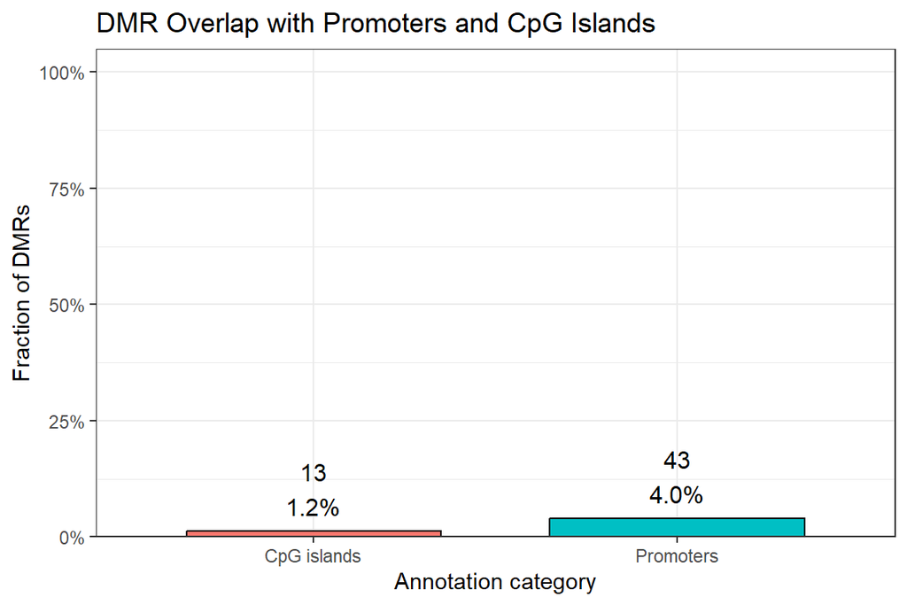

```r
ggplot(annotation_enrichment_summary, aes(x = Annotation, y = Fraction_of_DMRs, fill = Annotation)) +
  geom_col(show.legend = FALSE, color = "black", width = 0.7) +
  geom_text(
    aes(label = paste0(Number_of_DMRs, "\n", percent(Fraction_of_DMRs, accuracy = 0.1))),
    vjust = -0.3,
    size = 4
  ) +
  scale_y_continuous(
  labels = percent_format(accuracy = 1),
  limits = c(0, 1),
  expand = expansion(mult = c(0, 0.05))
  ) +
  labs(
    title = "DMR Overlap with Promoters and CpG Islands",
    x = "Annotation category",
    y = "Fraction of DMRs"
  ) +
  theme_bw()
```

Create a heatmap of top DMCs and DMRs (most significant). Explain clustering patterns across samples.

```r
# ------------------------------------------------------------
# Simple enrichment test using all tested CpGs as background
# ------------------------------------------------------------

background_cpgs <- as.data.table(dmlTest)

background_gr <- GRanges(
  seqnames = background_cpgs$chr,
  ranges = IRanges(
    start = background_cpgs$pos,
    end = background_cpgs$pos
  )
)

background_annotations <- annotate_regions(
  regions = background_gr,
  annotations = annotations,
  ignore.strand = TRUE,
  quiet = TRUE
)

background_annotations_df <- as.data.frame(background_annotations)

background_annotation_summary <- background_annotations_df %>%
  dplyr::mutate(
    CpG_id = paste(seqnames, start, end, sep = "_"),
    in_promoter = grepl("promoter", annot.type, ignore.case = TRUE),
    in_CGI = grepl("cpg_islands", annot.type, ignore.case = TRUE)
  ) %>%
  dplyr::group_by(CpG_id) %>%
  dplyr::summarise(
    promoter_overlap = any(in_promoter),
    CGI_overlap = any(in_CGI),
    .groups = "drop"
  )

# Promoter enrichment
promoter_matrix <- matrix(
  c(
    number_dmrs_in_promoters,
    number_dmrs_total - number_dmrs_in_promoters,
    sum(background_annotation_summary$promoter_overlap),
    nrow(background_annotation_summary) - sum(background_annotation_summary$promoter_overlap)
  ),
  nrow = 2,
  byrow = TRUE
)

promoter_enrichment <- fisher.test(promoter_matrix)

# CpG island enrichment
cgi_matrix <- matrix(
  c(
    number_dmrs_in_CGI,
    number_dmrs_total - number_dmrs_in_CGI,
    sum(background_annotation_summary$CGI_overlap),
    nrow(background_annotation_summary) - sum(background_annotation_summary$CGI_overlap)
  ),
  nrow = 2,
  byrow = TRUE
)

cgi_enrichment <- fisher.test(cgi_matrix)

enrichment_results <- data.frame(
  Annotation = c("Promoters", "CpG islands"),
  Odds_ratio = c(
    promoter_enrichment$estimate,
    cgi_enrichment$estimate
  ),
  P_value = c(
    promoter_enrichment$p.value,
    cgi_enrichment$p.value
  )
)

enrichment_results
```

```
   Annotation Odds_ratio      P_value
1   Promoters  0.5741073 0.0001529056
2 CpG islands  0.7462157 0.3332480202
```

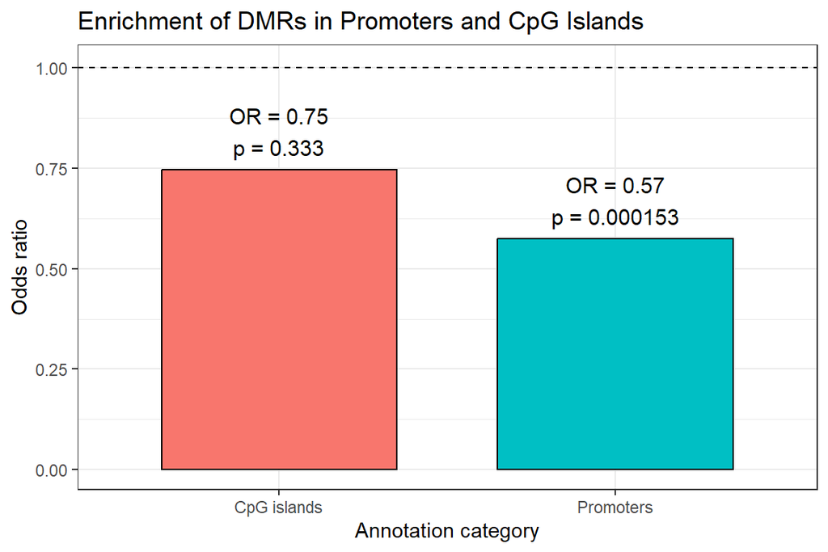

```r
ggplot(enrichment_results, aes(x = Annotation, y = Odds_ratio, fill = Annotation)) +
  geom_col(show.legend = FALSE, color = "black", width = 0.7) +
  geom_hline(yintercept = 1, linetype = "dashed") +
  geom_text(
    aes(label = paste0("OR = ", round(Odds_ratio, 2), "\np = ", signif(P_value, 3))),
    vjust = -0.3,
    size = 4
  ) +
  scale_y_continuous(
    limits = c(0, max(enrichment_results$Odds_ratio, na.rm = TRUE) * 1.35)
  ) +
  labs(
    title = "Enrichment of DMRs in Promoters and CpG Islands",
    x = "Annotation category",
    y = "Odds ratio"
  ) +
  theme_bw()
```

```r
# ------------------------------------------------------------
# 5. Heatmap of top DMCs and DMRs
# ------------------------------------------------------------

# Choose number of top sites/regions
top_n_dmcs <- 50
top_n_dmrs <- 50

# Select top DMCs by p-value
# top_dmcs <- dmcs %>%
#   arrange(pval) %>%
#   slice_head(n = top_n_dmcs)

top_dmcs <- dmcs_sig %>%
  dplyr::arrange(fdr) %>%
  dplyr::slice_head(n = top_n_dmcs)

head(top_dmcs)
```

```
      chr      pos        mu1        mu2       diff    diff.se      stat
   <char>    <int>      <num>      <num>      <num>      <num>     <num>
1:  chr20  4024043 0.98067515 0.09728543  0.8833897 0.05921245  14.91899
2:  chr20 48258675 0.06881530 0.98334742 -0.9145321 0.07754814 -11.79309
3:  chr20 23244407 0.06881530 0.98245444 -0.9136391 0.07820686 -11.68234
4:  chr20 61900109 0.07050297 0.97872686 -0.9082239 0.08406282 -10.80411
5:  chr20 61926186 0.13538030 0.98724249 -0.8518622 0.08116353 -10.49563
6:  chr20 55961401 0.09765725 0.98453824 -0.8868810 0.08501706 -10.43180
         phi1       phi2         pval          fdr
        <num>      <num>        <num>        <num>
1: 0.09548229 0.01722036 2.480160e-50 1.367510e-44
2: 0.05260081 0.06058823 4.237075e-32 1.168119e-26
3: 0.05260081 0.05974951 1.569147e-31 2.883988e-26
4: 0.05495819 0.05904585 3.291353e-27 4.536966e-22
5: 0.03292962 0.06163125 9.047409e-26 9.977121e-21
6: 0.04809141 0.06053024 1.774921e-25 1.631093e-20
```

```r
# ------------------------------------------------------------
# Extract methylation proportions from BS object
# ------------------------------------------------------------

cov_matrix <- getCoverage(BS, type = "Cov")  # total coverage
m_matrix <- getCoverage(BS, type = "M")      # methylated counts

# Methylation proportion per CpG per sample
meth_matrix <- m_matrix / cov_matrix

# Convert to data frame
meth_percent <- as.data.frame(meth_matrix)

# Add chromosome and position information
meth_percent$chr <- as.character(seqnames(rowRanges(BS)))
meth_percent$pos <- start(rowRanges(BS))

# Create site ID
meth_percent <- meth_percent %>%
  dplyr::mutate(site_id = paste(chr, pos, sep = "_"))


# Create site IDs for top DMCs
top_dmcs <- top_dmcs %>%
  dplyr::mutate(site_id = paste(chr, pos, sep = "_"))

# Filter methylation matrix to top DMCs
top_dmc_matrix <- meth_percent %>%
  dplyr::filter(site_id %in% top_dmcs$site_id)

rownames(top_dmc_matrix) <- top_dmc_matrix$site_id

# Keep only sample methylation columns
top_dmc_matrix <- top_dmc_matrix %>%
  dplyr::select(-chr, -pos, -site_id)

top_dmc_matrix <- as.matrix(top_dmc_matrix)

# Remove rows with missing or infinite values
top_dmc_matrix <- top_dmc_matrix[complete.cases(top_dmc_matrix), ]
top_dmc_matrix <- top_dmc_matrix[apply(top_dmc_matrix, 1, function(x) all(is.finite(x))), ]
```

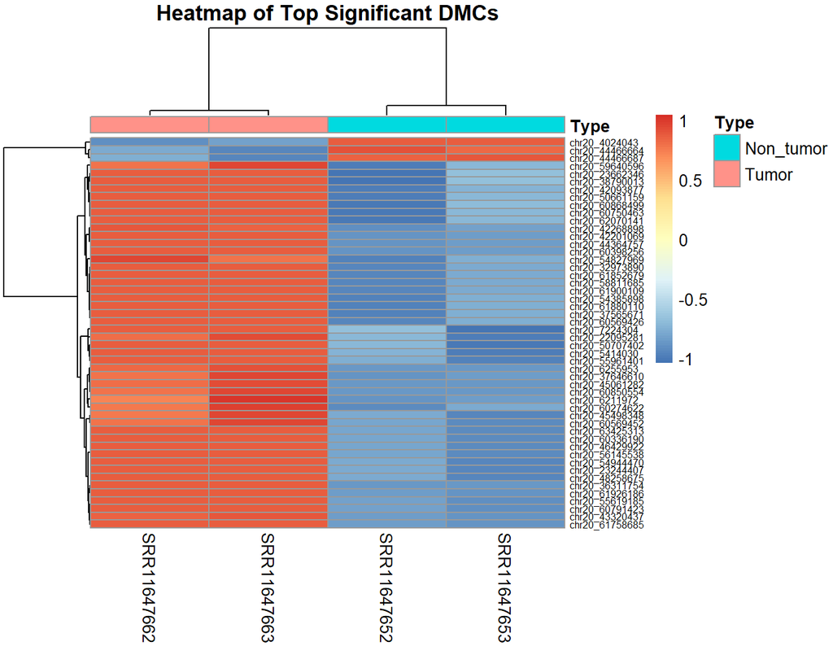

```r
pheatmap(
  top_dmc_matrix,
  scale = "row",
  annotation_col = annotation,
  clustering_distance_rows = "euclidean",
  clustering_distance_cols = "euclidean",
  clustering_method = "complete",
  show_rownames = TRUE,
  fontsize_row = 6,
  main = "Heatmap of Top Significant DMCs"
)
```

```r
# Select top DMRs by statistical evidence
# DSS DMR output uses areaStat; larger absolute areaStat = stronger regional signal
top_dmrs <- optimal_dmrs %>%
  dplyr::arrange(dplyr::desc(abs(areaStat))) %>%
  dplyr::slice_head(n = top_n_dmrs) %>%
  dplyr::mutate(
    DMR_id = paste0(chr, ":", start, "-", end)
  )

# Convert top DMRs to GRanges
top_dmrs_gr <- GRanges(
  seqnames = top_dmrs$chr,
  ranges = IRanges(
    start = top_dmrs$start,
    end = top_dmrs$end
  )
)

# Convert methylation CpG positions to GRanges
meth_gr <- GRanges(
  seqnames = meth_percent$chr,
  ranges = IRanges(
    start = meth_percent$pos,
    end = meth_percent$pos
  )
)

# Keep only sample methylation columns
meth_sample_cols <- setdiff(
  colnames(meth_percent),
  c("chr", "pos", "site_id")
)

mcols(meth_gr) <- meth_percent[, meth_sample_cols]

# Find CpGs that fall inside top DMRs
hits <- findOverlaps(meth_gr, top_dmrs_gr)

# Create overlap table
overlap_df <- data.frame(
  CpG_index = queryHits(hits),
  DMR_index = subjectHits(hits)
)

overlap_df$DMR_id <- top_dmrs$DMR_id[overlap_df$DMR_index]

# Extract methylation values
meth_values <- as.data.frame(mcols(meth_gr))
meth_values$CpG_index <- seq_len(nrow(meth_values))

# Join CpGs to DMRs
overlap_meth <- overlap_df %>%
  dplyr::left_join(meth_values, by = "CpG_index")

# Average methylation per DMR per sample
top_dmr_matrix <- overlap_meth %>%
  dplyr::select(-CpG_index, -DMR_index) %>%
  dplyr::group_by(DMR_id) %>%
  dplyr::summarise(
    dplyr::across(dplyr::all_of(meth_sample_cols), ~ mean(.x, na.rm = TRUE)),
    .groups = "drop"
  )

# Convert to matrix
top_dmr_matrix <- as.data.frame(top_dmr_matrix)
rownames(top_dmr_matrix) <- top_dmr_matrix$DMR_id

top_dmr_matrix <- top_dmr_matrix %>%
  dplyr::select(-DMR_id)

top_dmr_matrix <- as.matrix(top_dmr_matrix)

# Remove rows with missing or infinite values
top_dmr_matrix <- top_dmr_matrix[complete.cases(top_dmr_matrix), ]
top_dmr_matrix <- top_dmr_matrix[
  apply(top_dmr_matrix, 1, function(x) all(is.finite(x))),
]

# Optional: if too many rows are lost, check dimensions
dim(top_dmr_matrix)
```

```
[1] 50  4
```

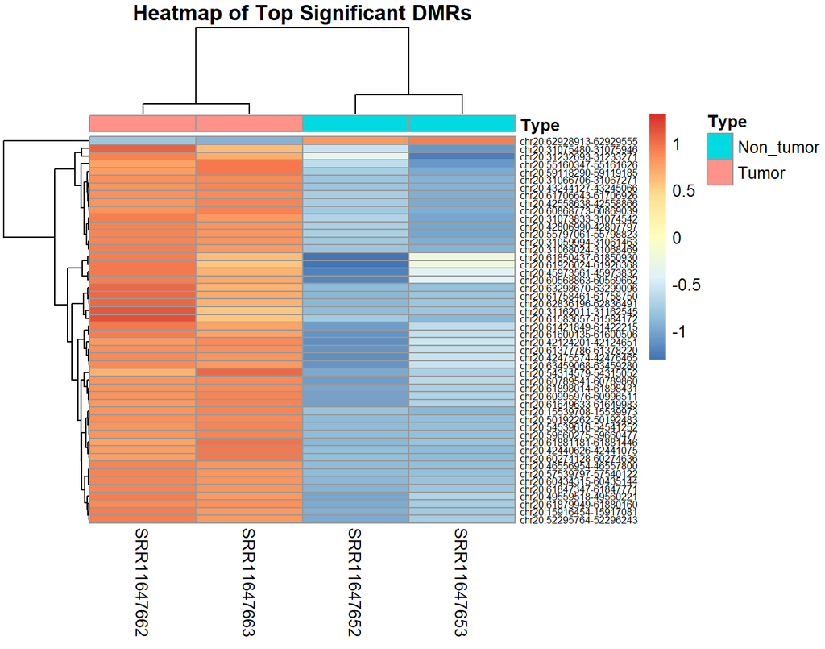

```r
# Heatmap
pheatmap(
  top_dmr_matrix,
  scale = "row",
  annotation_col = annotation,
  clustering_distance_rows = "euclidean",
  clustering_distance_cols = "euclidean",
  clustering_method = "complete",
  show_rownames = TRUE,
  fontsize_row = 6,
  main = "Heatmap of Top Significant DMRs"
)
```

# Biological interpretation

Perform functional enrichment analysis (e.g., GO, KEGG) using genes associated with DMRs and DMCs. You will have to investigate multiple variants (see next question)

Compare and describe enrichment results obtained from: - all DMR-associated genes VS only promoter-associated DMR genes - Hypermethylated DMCs VS hypomethylated DMCs

```r
# ------------------------------------------------------------
# Functional enrichment analysis
# ------------------------------------------------------------

# ------------------------------------------------------------
# Annotate DMCs
# ------------------------------------------------------------

dmc_annotations <- annotate_regions(
  regions = dmcs_gr,
  annotations = annotations,
  ignore.strand = TRUE,
  quiet = TRUE
)

dmc_annotations_df <- as.data.frame(dmc_annotations)

head(dmc_annotations_df)
```

```
  seqnames start   end width strand       diff         pval annot.seqnames
1    chr20 66115 66115     1      * -0.6537015 9.131026e-07          chr20
2    chr20 73851 73851     1      * -0.5727488 2.629966e-04          chr20
3    chr20 83091 83091     1      * -0.5052493 2.102323e-05          chr20
4    chr20 83091 83091     1      * -0.5052493 2.102323e-05          chr20
5    chr20 83091 83091     1      * -0.5052493 2.102323e-05          chr20
6    chr20 94886 94886     1      * -0.7007335 5.995349e-06          chr20
  annot.start annot.end annot.width annot.strand       annot.id
1           1    275147      275147            *    inter:17836
2           1    275147      275147            *    inter:17836
3       82250     86249        4000            +  1to5kb:349282
4       82672     86671        4000            +  1to5kb:349283
5           1    275147      275147            *    inter:17836
6       87360     96004        8645            + intron:1603007
        annot.tx_id annot.gene_id annot.symbol         annot.type
1              <NA>          <NA>         <NA>     hg38_cpg_inter
2              <NA>          <NA>         <NA>     hg38_cpg_inter
3 ENST00000608838.1        245938      DEFB125  hg38_genes_1to5kb
4 ENST00000382410.3        245938      DEFB125  hg38_genes_1to5kb
5              <NA>          <NA>         <NA>     hg38_cpg_inter
6 ENST00000608838.1        245938      DEFB125 hg38_genes_introns
```

```r
names(dmc_annotations_df)
```

```
 [1] "seqnames"       "start"          "end"            "width"
 [5] "strand"         "diff"           "pval"           "annot.seqnames"
 [9] "annot.start"    "annot.end"      "annot.width"    "annot.strand"
[13] "annot.id"       "annot.tx_id"    "annot.gene_id"  "annot.symbol"
[17] "annot.type"
```

```r
# ------------------------------------------------------------
# Helper function to extract gene symbols
# ------------------------------------------------------------

extract_gene_symbols <- function(annotation_df) {

  possible_gene_cols <- c(
    "annot.symbol",
    "symbol",
    "gene_name",
    "gene_symbol",
    "external_gene_name"
  )

  gene_col <- possible_gene_cols[possible_gene_cols %in% names(annotation_df)][1]

  if (is.na(gene_col)) {
    stop("No gene symbol column found. Check names(annotation_df).")
  }

  genes <- annotation_df[[gene_col]]
  genes <- genes[!is.na(genes)]
  genes <- genes[genes != ""]
  genes <- unique(genes)

  return(genes)
}

# ------------------------------------------------------------
# All DMR-associated genes
# ------------------------------------------------------------

all_dmr_genes <- extract_gene_symbols(dmr_annotations_df)

length(all_dmr_genes)
```

```
[1] 178
```

```r
head(all_dmr_genes)
```

```
[1] "DIDO1"     "CEBPB-AS1" "CEBPB"     "ZNF831"    "CDH4"      "PTPRT"
```

```r
# ------------------------------------------------------------
# Promoter-associated DMR genes
# ------------------------------------------------------------

promoter_dmr_annotations <- dmr_annotations_df %>%
  filter(grepl("promoter", annot.type, ignore.case = TRUE))

promoter_dmr_genes <- extract_gene_symbols(promoter_dmr_annotations)

length(promoter_dmr_genes)
```

```
[1] 25
```

```r
head(promoter_dmr_genes)
```

```
[1] "CEBPB-AS1"    "COL9A3"       "KCNQ2"        "LOC107985401" "ZNF334"
[6] "GHRH"
```

```r
# ------------------------------------------------------------
# Add methylation direction to DMCs
# ------------------------------------------------------------

# DSS DMC output usually has a column called diff.
# Positive diff = hypermethylated in group 1 compared with group 2.
# Negative diff = hypomethylated in group 1 compared with group 2.

dmcs_sig <- dmcs_sig %>%
  dplyr::mutate(
    DMC_id = paste(chr, pos, sep = "_"),
    methylation_direction = ifelse(diff > 0, "Hypomethylated", "Hypermethylated")
  )

dmc_annotations_df <- dmc_annotations_df %>%
  dplyr::mutate(
    DMC_id = paste(seqnames, start, sep = "_")
  )

dmc_annotations_with_direction <- dmc_annotations_df %>%
  dplyr::left_join(
    dmcs_sig %>% dplyr::select(DMC_id, methylation_direction),
    by = "DMC_id"
  )

# ------------------------------------------------------------
# Hyper- and hypomethylated DMC genes
# ------------------------------------------------------------

# Separate hyper- and hypomethylated DMC annotations
hyper_dmc_annotations <- dmc_annotations_with_direction %>%
  dplyr::filter(methylation_direction == "Hypermethylated")

hypo_dmc_annotations <- dmc_annotations_with_direction %>%
  dplyr::filter(methylation_direction == "Hypomethylated")

# Extract gene symbols
hyper_dmc_genes <- extract_gene_symbols(hyper_dmc_annotations)
hypo_dmc_genes <- extract_gene_symbols(hypo_dmc_annotations)


hyper_dmc_annotations <- dmc_annotations_with_direction %>%
  dplyr::filter(methylation_direction == "Hypermethylated")

hypo_dmc_annotations <- dmc_annotations_with_direction %>%
  dplyr::filter(methylation_direction == "Hypomethylated")


length(hyper_dmc_genes)
```

```
[1] 600
```

```r
length(hypo_dmc_genes)
```

```
[1] 104
```

```r
head(hyper_dmc_genes)
```

```
[1] "DEFB125"  "DEFB127"  "DEFB128"  "DEFB129"  "C20orf96" "TCF15"
```

```r
head(hypo_dmc_genes)
```

```
[1] "ANGPT4"        "SDCBP2-AS1"    "FKBP1A-SDCBP2" "LOC124904858"
[5] "LOC100289473"  "LOC102724545"
```

```r
# ------------------------------------------------------------
# Convert gene symbols to Entrez IDs
# ------------------------------------------------------------

library(clusterProfiler)
library(org.Hs.eg.db)

convert_to_entrez <- function(gene_symbols) {

  gene_symbols <- unique(gene_symbols)
  gene_symbols <- gene_symbols[!is.na(gene_symbols)]
  gene_symbols <- gene_symbols[gene_symbols != ""]

  converted <- bitr(
    gene_symbols,
    fromType = "SYMBOL",
    toType = "ENTREZID",
    OrgDb = org.Hs.eg.db
  )

  unique(converted$ENTREZID)
}

all_dmr_entrez <- convert_to_entrez(all_dmr_genes)
promoter_dmr_entrez <- convert_to_entrez(promoter_dmr_genes)
hyper_dmc_entrez <- convert_to_entrez(hyper_dmc_genes)
hypo_dmc_entrez <- convert_to_entrez(hypo_dmc_genes)
# ------------------------------------------------------------
# GO enrichment function
# ------------------------------------------------------------

run_go_enrichment <- function(entrez_genes) {

  if (length(entrez_genes) < 5) {
    return(NULL)
  }

  enrichGO(
    gene = entrez_genes,
    OrgDb = org.Hs.eg.db,
    keyType = "ENTREZID",
    ont = "BP",
    pAdjustMethod = "BH",
    pvalueCutoff = 0.05,
    qvalueCutoff = 0.2,
    readable = TRUE
  )
}

go_all_dmr <- run_go_enrichment(all_dmr_entrez)
go_promoter_dmr <- run_go_enrichment(promoter_dmr_entrez)
go_hyper_dmc <- run_go_enrichment(hyper_dmc_entrez)
go_hypo_dmc <- run_go_enrichment(hypo_dmc_entrez)
```

```r
# ------------------------------------------------------------
# GO enrichment tables
# ------------------------------------------------------------

if (!is.null(go_all_dmr)) {
  kable(
    head(as.data.frame(go_all_dmr), 10),
    caption = "Top GO biological process terms for all DMR-associated genes"
  )
}
```

Top GO biological process terms for all DMR-associated genes

| ID | Description | GeneRatio | BgRatio | RichFactor | FoldEnrichment | zScore | pvalue | p.adjust | qvalue | geneID | Count |
| --- | --- | --- | --- | --- | --- | --- | --- | --- | --- | --- | --- |

```r
if (!is.null(go_promoter_dmr)) {
  kable(
    head(as.data.frame(go_promoter_dmr), 10),
    caption = "Top GO biological process terms for promoter-associated DMR genes"
  )
}
```

Top GO biological process terms for promoter-associated DMR genes

| ID | Description | GeneRatio | BgRatio | RichFactor | FoldEnrichment | zScore | pvalue | p.adjust | qvalue | geneID | Count |
| --- | --- | --- | --- | --- | --- | --- | --- | --- | --- | --- | --- |